# Statistical Audit of the Global Index on Responsible AI (GIRAI)

Luciano Borgoglio

2024-06-07

# Executive summary and conclusions

- The *Global Index on Responsible AI* is found to be statistically very sound in terms of the correlation structure and in terms of the presence of a very significant latent variable underlying the data found via *Principal Component Analysis*.
- The framework is very consistent: the pillars measure a latent variable that accounts for a large amount (83.5%) of the variability of the data (well above the threshold of 70% usually considered good practice for composite indexes).
- Many indicators present salient quality attributes: specially too many zeroes and/or too few unique values, but the aggregation is successful in getting pillars and index scores with much better statistical qualities. This trait, of abundance of zeroes, is unsuprising to the extent that we are assessing very emergent phenomena.
- The correlation structure of the indicators belonging to each pillar is very good, with a vast majority of correlations in desired ranges: the *Index* is statistically very sound also at the level of the indicators that compose each pillar.
- The correlation structure is also very good between the indicators and the pillar to which they belong, between the indicators and the index and between the pillars themselves.
- Consistency of the framework in terms of (very high) Cronbach’s Alpha confirms the soundness of the index assessed via the structure of correlations and Principal Components Analysis.
- The framework was found very sound the way it already is, but some simulations were run just for illustration purposes in the appendix.
- Equal weighting of the pillars was experimented with, suggested by PCA weights and optimization procedures, and also in relation to the conceptual equal essentiality or complementarity of them.
- Some other aggregation formulas for the pillars, like a geometric weighted mean, was also explored in order to allow for less than perfect compensation between them (i.e.: considering them “essentials”). Exclusion of some indicators were also experimented with.
- The quality attributes of the indicators might be improved and costs might be reduced if eventually the data collection were to be semi-automated. Developing automated agents to perform this task with the researchers’ supervision might yield more granular, well-behaved and nuanced data with more distinct values, making more of a continuum and less of a set of categories. This would also save time, unify methods for all regions/hubs and assess a bigger set of dimensions more accurately. The fact that the data is the outcome of primarily an *online* research, makes the task, at least in principle, quite prone to semi-automation. This would, of course, entail extensive experimentation, but looks like a promising path to explore.
- In conclusion, the *Global Index on Responsible AI* is very statistically sound as it is. There is very little room (or need) to simplify and/or improve the *index*.

# Introduction

This notebook presents a full statistical audit of the *Global Index on Responsible AI (GIRAI)*. The main objectives are to assess the statistical soundness of the index and (if necessary) to suggest changes in the direction of improving it.

We will be leveraging the *R* package *COINr* (*CRAN, 2023*) whenever possible, which embeds current best practices for building and analyzing composite indexes, in a user-friendly framework that the *GIRAI* team will be able to use, with minimal adaptation, for other indexes or future versions of this one. The package was developed by European Commission’s *Joint Research Centre*, a renowned authority in statistical audits.

We will go through the full data cycle in this document: download the data, perform the analysis, present the results and provide the recommendations. This allows for a consistent and straightforward procedure that also opens the door for a full automation of the whole process.

This document can be read in a browser, where you will be able to interact with tables and graphs. The outputs of the chunks of code can be quite verbose but a choice has been made of keeping them, in order to show fully the inner workings of the processes and for *GIRAI* team to adapt it more easily for other uses.

# Initialization, data downloading and pre-processing

We will first install necessary libraries, retrieve the data and inspect it:

```r
# Remove all objects from the environment and clean memory
rm(list = ls())
gc()

# Install packages outside CRAN separately
devtools::install_github("bluefoxr/iCOINr")
```

```r
# Function to check and install packages
install_if_not_installed <- function(pkg) {
  if (!requireNamespace(pkg, quietly = TRUE)) {
    suppressMessages(install.packages(pkg, dependencies = TRUE))
  }
  suppressMessages(library(pkg, character.only = TRUE))
}

# List of required packages
required_packages <- c("COINr", "tidyr", "dplyr", "stringr", "DT", "Hmisc", "reactable", "ggbiplot", "ggplot2", "factoextra", "FactoMineR", "cluster", "psych", "Amelia", "countrycode", "WDI", "iCOINr", "readxl", "tidyverse", "openxlsx", "leaflet", "rnaturalearth", "rnaturalearthdata", "sf", "ggpubr", "ggthemes")

# Install and load required packages
lapply(required_packages, install_if_not_installed)

# Load the XLSX file into the environment as GBD_dataset and suppress warnings
suppressWarnings({
  GIRAI_dataset <- read_excel("details.xlsx")
})
```

```r
# Dimensions/structure of the dataset
glimpse(GIRAI_dataset)
```

```
## Rows: 4,031
## Columns: 112
## $ country                  <chr> "Afghanistan", "Afghanistan", "Afghanistan", …
## $ ISO_alpha3_code          <chr> "AFG", "AFG", "AFG", "AFG", "AFG", "AFG", "AF…
## $ GIRAI_region             <chr> "Asia and Oceania", "Asia and Oceania", "Asia…
## $ GIRAI_subregion          <chr> "South West Asia", "South West Asia", "South …
## $ UN_region                <chr> "Asia", "Asia", "Asia", "Asia", "Asia", "Asia…
## $ UN_sub_region            <chr> "Southern Asia", "Southern Asia", "Southern A…
## $ regional_hub             <chr> "LIRNEasia", "LIRNEasia", "LIRNEasia", "LIRNE…
## $ dimension                <chr> "National Responsible AI Capacities", "Respon…
## $ sub_dimension            <chr> "Investments", "Technology-Specific Regulatio…
## $ thematic_area            <chr> "AI Ethics Research", "Algorithmic Decision-M…
## $ scoring                  <chr> "non-scoring", "non-scoring", "non-scoring", …
## $ case                     <chr> "case2", "case1", "case2", "case1", "case2", …
## $ ta_score                 <dbl> 0.000000, 0.000000, 0.000000, 0.000000, 0.000…
```

[output cut: 99 more lines]

We have a dataset of 4031 lines and 112 columns. The dataset is machine readable, the naming of variables are intuitive and the documentation is clear. All numeric and character fields are correctly formatted and the names of the variables are intuitive.

We will remove *Bosnia and Herzegovina* since doesn’t enter the ranking. We will also be working with scoring thematic areas only, since they are the only ones that get into the index calculation. We can therefore also delete all non-scoring thematic areas data from our database:

```r
# Filter rows where "scoring" is not equal to "non-scoring" and let go BIH
GIRAI_dataset <- GIRAI_dataset %>%
  filter(scoring != "non-scoring", ISO_alpha3_code != "BIH")
```

Next, we will transform the dataframe in order to fit it into a *COIN*, the *R* object that will be manipulated by *COINr* package.

## *COINr* data preprocessing

As mentioned, throughout this audit we will make extensive use of *COINr*. This *R* package provides a harmonised development environment for composite indicators that includes all common operations from indicator selection, data treatment and imputation up to aggregation, presentation of results and uncertainty analysis. *COINr* enables development, visualisation and exploration of methodological variations, and encourages transparency and reproducibility. This enables a neat and structured environment, simplifies the syntax of functions, and also allows comparisons between different versions of the same index, as well as global sensitivity analysis (*Becker et al, 2022*).

We will preprocess the data in order to be suitable for the *COINr* workflow. From the database downloaded, we now need to build two dataframes with the following schema:

1. *iData*: A dataframe that has the *countries* in rows and *indicators* in columns.

The first columns should be *uName* and *uCode*; then all indicators.

2. *iMeta*: A dataframe that has the *indicators* in rows and the following columns:

   ```
        * Level
        * iCode
        * iName
        * Direction
        * Weight
        * Unit
        * Parent
        * Type
   ```

### *iData* dataframe

The *iData* dataframe is where the bulk of the data from the downloaded database will be located. We will be extracting the indicators, which is the adequate level of analysis for a statistical audit of the index.

We will transform the downloaded dataframe into the desired format where the rows represent countries and the columns represent indicators (with cell values from the score column) and we will rename the columns suitably for the processing that *COINr* will do later.

In this process, we will create columns for all 57 indicators (3 pillars x 19 thematic areas). Since each indicator can be considered the intersection between a pillar and a thematic area, the naming we will use will follow that closely: for the indicator of pillar *Frameworks* and thematic area *Bias and Unfair Discrimination* (thematic area number 1), the indicator will be coded as *fr_ta1* and named *Frameworks - Bias and Unfair Discrimination*.

We will take the normalised values from the *details* database, since the type of normalisation is not a major concern for their different options to be simulated here (as opposed to aggregation by geometric or arithmetic mean, weighting of pillars, inclusion/exclusion of indicators, etc., which might more relevant topics for the stakeholders). The values for the indicators that we will take for this audit are not only normalised but also adjusted for effectiveness via secondary sources (see Methodology).

Thematic areas are indexed by arranging the dimensions alphabetically and then arranging alphabetically the thematic areas belonging to each (as is the common usage so far), information that we will locate in *thematic_areas* dataframe along with the whole hierarchical structure that includes the aggregation of thematic areas into sub dimensions and dimensions:

```r
# Get a list of thematic areas ordered within dimensions which are also ordered alphabetically
thematic_areas <- GIRAI_dataset %>%
  select(dimension, sub_dimension, thematic_area) %>%  # Include sub_dimension
  distinct() %>%
  arrange(dimension, sub_dimension, thematic_area) %>%
  mutate(
    ta_index = sprintf("%02d", row_number()),  # Creates a number for each thematic area with two digits
    ta_code = paste0("ta", ta_index)  # Generate ta_code from ta_index
  )

thematic_areas %>%
  reactable()
```

| dimension | sub_dimension | thematic_area | ta_index | ta_code |
| --- | --- | --- | --- | --- |
| Human Rights and AI | Civil and Political Rights | Bias and Unfair Discrimination | 01 | ta01 |
| Human Rights and AI | Civil and Political Rights | Children's Rights | 02 | ta02 |
| Human Rights and AI | Civil and Political Rights | Data Protection and Privacy | 03 | ta03 |
| Human Rights and AI | Civil and Political Rights | Gender Equality | 04 | ta04 |
| Human Rights and AI | Civil and Political Rights | Public Participation and Awareness | 05 | ta05 |
| Human Rights and AI | Socio-Economic Rights | Cultural and Linguistic Diversity | 06 | ta06 |
| Human Rights and AI | Socio-Economic Rights | Labour Protection and Right to Work | 07 | ta07 |
| National Responsible AI Capacities | Competencies | International Cooperation | 08 | ta08 |
| National Responsible AI Capacities | Competencies | Public Sector Skills Development | 09 | ta09 |
| National Responsible AI Capacities | Institutions | Competitions Authorities | 10 | ta10 |

[output cut: 9 more lines]

We have now 19 (scoring) thematic areas.

Sub-dimensions are also indexed for simplicity:

```r
# Create sub_dimensions dataframe
sub_dimensions <- thematic_areas %>%
  distinct(sub_dimension, .keep_all = TRUE) %>%  # Keep unique combinations
  mutate(
    sub_index = row_number(),  # Add ordered index column
    sub_code = paste0("sub_", sub_index)  # Create sub_code column
  ) %>%
  select(-ta_index, -ta_code, -thematic_area)  # Drop columns ta_index and ta_code

# Reorder columns
sub_dimensions <- sub_dimensions %>%
  select(sub_dimension, dimension, sub_index, sub_code)

sub_dimensions %>%
  reactable()
```

| sub_dimension | dimension | sub_index | sub_code |
| --- | --- | --- | --- |
| Civil and Political Rights | Human Rights and AI | 1 | sub_1 |
| Socio-Economic Rights | Human Rights and AI | 2 | sub_2 |
| Competencies | National Responsible AI Capacities | 3 | sub_3 |
| Institutions | National Responsible AI Capacities | 4 | sub_4 |
| Enabling Policies | Responsible AI Governance | 5 | sub_5 |
| Rule of Law | Responsible AI Governance | 6 | sub_6 |
| Technical Standards | Responsible AI Governance | 7 | sub_7 |

We have 7 sub-dimensions.

### Indicators and country codes and names

```r
# Create a distinct dataset of ISO_alpha3_code and country
iData <- GIRAI_dataset %>%
  distinct(ISO_alpha3_code, country) %>%
  rename(uCode = ISO_alpha3_code, uName = country)

# Function to merge thematic scores with base data
merge_thematic_scores <- function(base_data, score_data, thematic_area_index, prefix, score_col) {
  # Retrieve the name of the thematic area using the index
  thematic_area_name <- thematic_areas$thematic_area[thematic_area_index]

  # Filter data for the current thematic area
  score_df <- score_data %>%
    filter(thematic_area == thematic_area_name) %>%
    select(uCode = ISO_alpha3_code, score = {{ score_col }})

  # Format the thematic_area_index as two digits and rename the 'score' column
  colnames(score_df)[which(colnames(score_df) == "score")] <- paste0(prefix, "_ta", sprintf("%02d", thematic_area_index))

  # Join scores back to the main dataframe
  base_data <- left_join(base_data, score_df, by = "uCode")

  return(base_data)
}

# Loop through each index of thematic areas using adjusted (and normalised) values
for (index in seq_along(thematic_areas$thematic_area)) {
  iData <- merge_thematic_scores(iData, GIRAI_dataset, index, "fr", "fr_adjust_score")
  iData <- merge_thematic_scores(iData, GIRAI_dataset, index, "ga", "ga_adjust_score")
  iData <- merge_thematic_scores(iData, GIRAI_dataset, index, "nsa", "nsa_adjust_score")
}
```

We have now a dataframe of 138 rows (countries) * 59 columns (3 pillars x 19 thematic areas = 57 -normalised and adjusted- primary indicators and 2 other columns -located at the beggining- with countries’ -ISO3- codes and names).

### Thematic areas

We will add *ta_score* from *GIRAI_dataset*, in order to calculate dimensions and sub dimensions, later aggregating them. Let us first build a wide dataframe of thematic areas scores by country and then join to iData.

```r
# Pivot wider to convert long format to wide format
wide_tas <- GIRAI_dataset %>%
  select(ISO_alpha3_code, thematic_area, ta_score) %>%
  pivot_wider(names_from = thematic_area,
              values_from = ta_score)

# Match ta_code with thematic_area in thematic_areas dataframe
ta_mapping <- thematic_areas %>%
  select(thematic_area, ta_code)

# Rename columns in wide_tas dataframe and reorder
wide_tas <- wide_tas %>%
  rename_with(
    ~ ta_mapping$ta_code[match(., ta_mapping$thematic_area)],
    -ISO_alpha3_code
  ) %>%
  select(ISO_alpha3_code, ta01, ta02, ta03, ta04, ta05, ta06, ta07, ta08, ta09, ta10, ta11, ta12, ta13, ta14, ta15, ta16, ta17, ta18, ta19)

# Join
iData <- left_join(iData, wide_tas, by = c("uCode" = "ISO_alpha3_code"))
```

### Dimensions and sub dimensions

We will calculate those aggregations of thematic areas here. Even if dimensions and sub dimensions don’t enter the actual scoring, it will be useful to have them in the COIN object in order to exploit, for instance, the package’s visualization capabilities. Let us remember the hierarchical structure of dimensions, sub dimensions and thematic areas:

```r
thematic_areas %>%
  reactable()
```

| dimension | sub_dimension | thematic_area | ta_index | ta_code |
| --- | --- | --- | --- | --- |
| Human Rights and AI | Civil and Political Rights | Bias and Unfair Discrimination | 01 | ta01 |
| Human Rights and AI | Civil and Political Rights | Children's Rights | 02 | ta02 |
| Human Rights and AI | Civil and Political Rights | Data Protection and Privacy | 03 | ta03 |
| Human Rights and AI | Civil and Political Rights | Gender Equality | 04 | ta04 |
| Human Rights and AI | Civil and Political Rights | Public Participation and Awareness | 05 | ta05 |
| Human Rights and AI | Socio-Economic Rights | Cultural and Linguistic Diversity | 06 | ta06 |
| Human Rights and AI | Socio-Economic Rights | Labour Protection and Right to Work | 07 | ta07 |
| National Responsible AI Capacities | Competencies | International Cooperation | 08 | ta08 |
| National Responsible AI Capacities | Competencies | Public Sector Skills Development | 09 | ta09 |
| National Responsible AI Capacities | Institutions | Competitions Authorities | 10 | ta10 |

[output cut: 9 more lines]

So, we will be basically taking means of thematic areas scores, aggregating them in dimensions and sub dimensions, respectively.

#### Dimensions

Each dimension score is the mean of the score of the thematic areas that compose it:

```r
# Check weighting if something else is decided / TODO: Check
iData <- iData %>%
  mutate(
    hr = rowMeans(select(., starts_with("ta"))[, 1:7]),
    cap = rowMeans(select(., starts_with("ta"))[, 8:10]),
    gov = rowMeans(select(., starts_with("ta"))[, 11:19])
  )
```

#### Sub-dimensions

As already shown, we will be naming/indexing the seven sub-dimensions this way:

```r
sub_dimensions %>%
  reactable()
```

| sub_dimension | dimension | sub_index | sub_code |
| --- | --- | --- | --- |
| Civil and Political Rights | Human Rights and AI | 1 | sub_1 |
| Socio-Economic Rights | Human Rights and AI | 2 | sub_2 |
| Competencies | National Responsible AI Capacities | 3 | sub_3 |
| Institutions | National Responsible AI Capacities | 4 | sub_4 |
| Enabling Policies | Responsible AI Governance | 5 | sub_5 |
| Rule of Law | Responsible AI Governance | 6 | sub_6 |
| Technical Standards | Responsible AI Governance | 7 | sub_7 |

Let us calculate the sub dimensions:

```r
iData <- iData %>%
  mutate(
    sub_1 = rowMeans(select(., starts_with("ta"))[, 1:5]),
    sub_2 = rowMeans(select(., starts_with("ta"))[, 6:7]),
    sub_3 = rowMeans(select(., starts_with("ta"))[, 8:9]),
    sub_4 = rowMeans(select(., starts_with("ta"))[, 10]),
    sub_5 = rowMeans(select(., starts_with("ta"))[, 11:12]),
    sub_6 = rowMeans(select(., starts_with("ta"))[, 13:18]),
    sub_7 = rowMeans(select(., starts_with("ta"))[, 19])
  )
```

### Crossings

We will build other auxiliary (also non-scoring) indicators that will exploit the double-sided design of the index. These indicators are *dimensions in pillar*. The other way around, *pillars in dimension*, yields the same results as will be shown later, which is why they will be omitted.

#### Dimensions in pillar

The total score for the pillar for a unit is the mean of all indicators corresponding to that pillar. The naming convention will put first the code of the dimension, then a slash, then the pillar.

For instance, for the case of *Frameworks*, the total score for Canada (CAN) would be:

$$\text{fr}_{\text{CAN}} =
\frac{\text{fr_ta1}_{\text{CAN}} + \text{fr_ta2}_{\text{CAN}} + \ldots +
\text{fr_ta19}_{\text{CAN}}}{19}$$

We can compute *partial* means/scores from this, corresponding to each dimension (within the pillar). For instance, for the case of *Human Rights and AI* in *Frameworks* pillar:

$$\text{hr_fr}_{\text{CAN}} =
\frac{\text{fr_ta1}_{\text{CAN}} + \text{fr_ta2}_{\text{CAN}} + \cdots +
\text{fr_ta7}_{\text{CAN}}}{7}$$

For *National Responsible AI Capacities* dimension in *Government actions* pillar:

$$\text{cap_ga}_{\text{CAN}} =
\frac{\text{ga_ta8}_{\text{CAN}} + \ldots +
\text{ga_ta10}_{\text{CAN}}}{3}$$

$$\text{gov_nsa}_{\text{CAN}} =
\frac{\text{nsa_ta11}_{\text{CAN}} + \text{nsa_ta12}_{\text{CAN}} +
\ldots + \text{nsa_ta19}_{\text{CAN}}}{9}$$

The same logic applies for the other six crossings. Now, let us create these new nine variables in *iData* dataframe:

```r
# Calculation of dimensions in pillars
iData <- iData %>%
  mutate(
    hr_fr = rowMeans(select(., starts_with("fr_ta"))[, 1:7]),
    hr_ga = rowMeans(select(., starts_with("ga_ta"))[, 1:7]),
    hr_nsa = rowMeans(select(., starts_with("nsa_ta"))[, 1:7]),
    cap_fr = rowMeans(select(., starts_with("fr_ta"))[, 8:10]),
    cap_ga = rowMeans(select(., starts_with("ga_ta"))[, 8:10]),
    cap_nsa = rowMeans(select(., starts_with("nsa_ta"))[, 8:10]),
    gov_fr = rowMeans(select(., starts_with("fr_ta"))[, 11:19]),
    gov_ga = rowMeans(select(., starts_with("ga_ta"))[, 11:19]),
    gov_nsa = rowMeans(select(., starts_with("nsa_ta"))[, 11:19])
  )

dim(iData)
```

```
## [1] 138  97
```

So far, we have *iData* dataframe with 97 variables (from *details* plus some aggregations from it) for our 138 countries.

#### Pillars in dimension

For the sake of completeness, we will confirm the commutative property of the crossings, that is, that the order doesn’t alter the product, which means that the pillars in dimensions calculation would yield the same results as the dimensions in pillar calculation.

The total score for the dimension for a unit (country or groups of them) is the sum of all indicators corresponding to that dimension (from pillars *fr*, *ga* and *nsa*). The naming convention will put first the code of the pillar, then a slash, then the dimension.

For instance, for the case of *Human Rights and AI*, the total score for *Canada* (CAN) would be the mean of all indicators belonging to that dimension, from *any* pillar:

$$\text{hr}_{\text{CAN}} =
\frac{{\text{fr_ta1}_{\text{CAN}} + \text{ga_ta1}_{\text{CAN}} +
\text{nsa_ta1}_{\text{CAN}} + \ldots + \text{fr_ta7}_{\text{CAN}} +
\text{ga_ta7}_{\text{CAN}} +
\text{nsa_ta7}_{\text{CAN}}}}{21}$$

We can compute *partial* means from this, corresponding to each pillar. For instance, for the case of *Frameworks*:

$$\text{fr_hr} =
\frac{{\text{fr_ta1}_{\text{CAN}} + \text{fr_ta2}_{\text{CAN}} + \ldots
+ \text{fr_ta7}_{\text{CAN}}}}{7}$$

Which is exactly the same expression we found for the *Human Rights and AI* dimension in *Frameworks* pillar before:

$$\text{fr_hr} = \text{hr_fr} =
\frac{{\text{fr_ta1}_{\text{CAN}} + \text{fr_ta2}_{\text{CAN}} + \ldots
+ \text{fr_ta7}_{\text{CAN}}}}{7}$$

Hence, we will not calculate the pillars in dimension crossings since they yield the same results as the dimensions in pillar already calculated.

### *iMeta* dataframe

Let us first build the part of *iMeta* that holds the information from the indicators (Level = 1).

```r
# Function to fill in the indicator names
fill_indicator_names <- function(code) {
  if (grepl("^fr", code)) {
    # Extract the number from the column name
    number <- as.numeric(gsub("fr_ta", "", code))
    # Look up the thematic area name using the number
    thematic_area <- thematic_areas$thematic_area[thematic_areas$ta_index == number]
    return(paste("Frameworks -", thematic_area))
  } else if (grepl("^ga", code)) {
    number <- as.numeric(gsub("ga_ta", "", code))
    thematic_area <- thematic_areas$thematic_area[thematic_areas$ta_index == number]
    return(paste("Government Actions -", thematic_area))
  } else if (grepl("^nsa", code)) {
    number <- as.numeric(gsub("nsa_ta", "", code))
    thematic_area <- thematic_areas$thematic_area[thematic_areas$ta_index == number]
    return(paste("Non-State Actors -", thematic_area))
  } else if (grepl("^sec", code)) {
    # Match the code to the 'code' in the secondary_indicators and fetch the corresponding 'name'
    indicator_name <- secondary_indicators$name[secondary_indicators$code == code]
    return(indicator_name)
  } else {
    return(NA) # Return NA for codes not matching any pattern
  }
}

# Fill in the indicator names
indicators <- data.frame(
  code = colnames(iData)[3:59],
  name = sapply(colnames(iData)[3:59], fill_indicator_names)
)

# Create first section iMeta dataframe with indicators (level 1)
iMeta1 <- data.frame(
  Level = 1,
  iCode = indicators$code,
  iName = indicators$name,
  Direction = 1,
  Weight = 1,
  Unit = "Score",
  Parent = ifelse(grepl("^fr", indicators$code), "fr",
                  ifelse(grepl("^ga", indicators$code), "ga",
                         ifelse(grepl("^nsa", indicators$code), "nsa",
                                ifelse(grepl("^sec", indicators$code), "sec", NA)))),
  Type = "Indicator"
)
```

Now let us continue with the next section/level 2 in *iMeta*, the aggregation of indicators in pillars.

```r
# Create iMeta2 dataframe
iMeta2 <- data.frame(
  Level = 2,                    # Level 2
  iCode = c("fr", "ga", "nsa"), # Pillar codes
  iName = c("Frameworks", "Government Actions", "Non-State Actors"), # Check spelling
  Direction = 1,                # Fill with appropriate values if known
  Weight = c(40, 40, 20),       # Weights
  Unit = "Score",               # Fill with appropriate values if known
  Parent = "index",             # Parent is "index"
  Type = "Aggregate"            # Type is "Aggregate"
)
```

Now the index or level = 3:

```r
# Create iMeta3 dataframe
iMeta3 <- data.frame(
  Level = 3,                    # Level 3
  iCode = "index",              # Code for the index
  iName = "Global Index on Responsible AI",              # Add later!!! Add to iData and extract here.
  Direction = 1,               # Fill with appropriate values if known
  Weight = 1,                  # Fill with appropriate values if known
  Unit = "Score",                    # Fill with appropriate values if known
  Parent = NA,                  # Fill with appropriate values if known
  Type = "Aggregate"            # Type is "Aggregate"
)
```

Now all “other” variables from *iData* (thematic areas, dimensions and sub-dimensions) that don’t enter the scoring:

```r
# For the first 19 rows
indicators_nonscoring1 <- thematic_areas %>%
  select(ta_code, thematic_area) %>%
  mutate(code = ta_code, name = thematic_area) %>%
  select(code, name)

# For the next 3 lines
indicators_nonscoring2 <- data.frame(
  code = colnames(iData)[79:81],
  name = unique(thematic_areas$dimension)
)

indicators_nonscoring3 <- data.frame(
  code = colnames(iData)[82:88],
  name = sub_dimensions$sub_dimension
)

map_combinations_to_names <- function(code) {
  if (startsWith(code, "hr")) {
    pillar_name <- "Human Rights and AI"
  } else if (startsWith(code, "cap")) {
    pillar_name <- "National Responsible AI Capacities"
  } else if (startsWith(code, "gov")) {
    pillar_name <- "Responsible AI Governance"
  } else {
    return(NA)
  }

  if (endsWith(code, "fr")) {
    thematic_area <- "Frameworks"
  } else if (endsWith(code, "ga")) {
    thematic_area <- "Government Actions"
  } else if (endsWith(code, "nsa")) {
    thematic_area <- "Non-State Actors"
  } else {
    return(NA)
  }

  return(paste(pillar_name, thematic_area, sep = " - "))
}

# Apply the function to generate names for each code
indicators_nonscoring4 <- data.frame(
  code = colnames(iData)[89:97],
  name = sapply(colnames(iData)[89:97], map_combinations_to_names)
)

# Combine the dataframes
indicators_nonscoring <- rbind(indicators_nonscoring1, indicators_nonscoring2, indicators_nonscoring3, indicators_nonscoring4)

# Create iMeta4 dataframe
iMeta4 <- data.frame(
  Level = rep(NA, 38),                             # NA for all rows
  iCode = colnames(iData)[60:97],
  iName = indicators_nonscoring$name,
  Direction = rep(NA, 38),                         # NA for all rows
  Weight = rep(NA, 38),                            # NA for all rows
  Unit = c(rep("Score", 38)),   # Updated values for the last three rows
  Parent = rep(NA, 38),                            # NA for all rows
  Type = rep("Other", 38)                          # "Other" for all rows
)
```

Now let us combine the dataframes

```r
# Combine iMeta1, iMeta2, iMeta3 and iMeta4 into iMeta
iMeta <- rbind(iMeta1, iMeta2, iMeta3, iMeta4)
```

Let us check that iData and iMeta dataframes are well constructed:

```r
check_iData(iData, quietly = FALSE)
```

```
## iData checked and OK.
```

```r
check_iMeta(iMeta, quietly = FALSE)
```

```
## iMeta checked and OK.
```

Both dataframes are well constructed, so we can move on.

## *COINr* pipeline

We will build the *COINr* object with the dataframes we built and then plot the framework in two different versions:

```r
# Assemble COIN
GIRAI <- new_coin(iData = iData,
                  iMeta = iMeta,
                  level_names = c("Indicator", "Pillar", "Index"))
```

```
## iData checked and OK.
```

```
## iMeta checked and OK.
```

```
## Written data set to .$Data$Raw
```

```r
GIRAI
```

```
## --------------
## A coin with...
## --------------
## Input:
##   Units: 138 (AFG, ALB, ARE, ...)
##   Indicators: 57 (fr_ta01, fr_ta02, fr_ta03, ...)
##   Denominators: 0 ()
##   Groups: 0 (none)
##
## Structure:
##   Level 1 Indicator: 57 indicators (fr_ta01, fr_ta02, fr_ta03, ...)
##   Level 2 Pillar: 3 groups (fr, ga, nsa)
##   Level 3 Index: 1 groups (index)
##
## Data sets:
##   Raw (138 units)
```

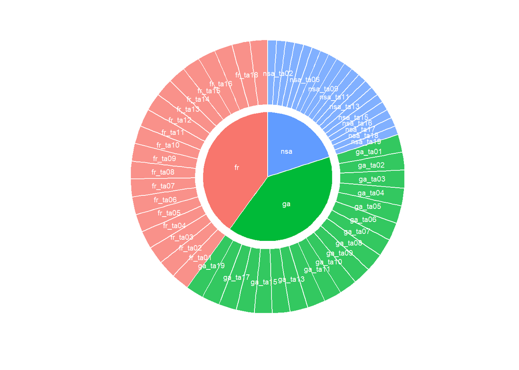

```r
# plot framework
plot_framework(GIRAI, transparency = TRUE)
```

The size of each component is reflected by its weight and the weight of its parent, i.e. its “effective weight” in the framework.

### Statistical qualities of indicators (inputs)

In this section we will check for the basic statistical properties of indicators before aggregation in the pillars and index. The other *COINr* steps of screening, imputing missing values and normalising, are not needed in this audit since we will work with normalised and adjusted indicators, but those steps are included in an appendix for completeness. What are the main statistical properties of the 57 indicators?

```r
# get table of indicator statistics for raw data set
get_stats(GIRAI, dset = "Raw", out2 = "df") |>
  reactable()
```

| iCode | Min | Max | Mean | Median | Std | Skew | Kurt | N.Avail | N.NonZero | N.Unique | N.Same | Frc.Avail | Frc.NonZero | Frc.Unique | Frc.Same | Flag.Avail | Flag.NonZero | Flag.Unique | Flag.SkewKurt |
| --- | --- | --- | --- | --- | --- | --- | --- | --- | --- | --- | --- | --- | --- | --- | --- | --- | --- | --- | --- |
| fr_ta01 | 0 | 95.8 | 14.2 | 0 | 24.8 | 1.55 | 1.15 | 138 | 40 | 41 | 98 | 1 | 0.29 | 0.297 | 0.71 | ok | LOW | LOW | ok |
| ga_ta01 | 0 | 98.6 | 22 | 0 | 35.3 | 1.12 | -0.531 | 138 | 41 | 41 | 97 | 1 | 0.297 | 0.297 | 0.703 | ok | LOW | LOW | ok |
| nsa_ta01 | 0 | 100 | 24.9 | 0 | 31.8 | 1.02 | -0.206 | 138 | 66 | 44 | 72 | 1 | 0.478 | 0.319 | 0.522 | ok | LOW | LOW | ok |
| fr_ta02 | 0 | 96.3 | 15.5 | 0 | 31.3 | 1.69 | 1.11 | 138 | 30 | 30 | 108 | 1 | 0.217 | 0.217 | 0.783 | ok | LOW | LOW | ok |
| ga_ta02 | 0 | 97 | 18.5 | 0 | 32.6 | 1.35 | 0.107 | 138 | 36 | 36 | 102 | 1 | 0.261 | 0.261 | 0.739 | ok | LOW | LOW | ok |
| nsa_ta02 | 0 | 100 | 12.3 | 0 | 23.9 | 2.15 | 4.01 | 138 | 39 | 29 | 99 | 1 | 0.283 | 0.21 | 0.717 | ok | LOW | LOW | OUT |
| fr_ta03 | 0 | 98.9 | 29.5 | 0 | 34.3 | 0.634 | -1.12 | 138 | 67 | 67 | 71 | 1 | 0.486 | 0.486 | 0.514 | ok | LOW | LOW | ok |
| ga_ta03 | 0 | 98.6 | 28.4 | 0 | 36 | 0.661 | -1.26 | 138 | 57 | 56 | 81 | 1 | 0.413 | 0.406 | 0.587 | ok | LOW | LOW | ok |
| nsa_ta03 | 0 | 100 | 27.2 | 9.63 | 33.2 | 0.865 | -0.657 | 138 | 71 | 54 | 67 | 1 | 0.514 | 0.391 | 0.486 | ok | ok | LOW | ok |
| fr_ta04 | 0 | 95.8 | 8.14 | 0 | 19.3 | 2.37 | 4.86 | 138 | 24 | 25 | 114 | 1 | 0.174 | 0.181 | 0.826 | ok | LOW | LOW | OUT |

[output cut: 47 more lines]

50 (out of 57) indicators have a high proportion (more than 50% of is values) of zeroes (*Flag.NonZero*). Indicator *fr_ta10* has the the lowest percent of non-zero values (7.97%), followed by *ga_ta13* and *ga_ta16*.

Related to the recurrence of zeroes, 55 indicators have a too low proportion (less than 50%) of unique/distinct/different values (*Flag.Unique*), mostly because are precisely the zeroes that tend to repeat, which is not surprising given the such emerging topic that is being measured. It is to be expected that when the countries go up the ladder of *Responsible AI*, this attribute of the distributions will tend to improve.

*nsa_ta16*, *fr_ta16*, *nsa_ta13*, *ga_ta13*, *nsa_ta10*, *fr_ta10*, *fr_ta04* and *nsa_ta02* present some outliers (skewness and kurtosis exceeding appropriate thresholds), which might suggest some treatment.

These correspond to thematic areas *Public Procurement*, *Access to Remedy and Redress*, *Competitions Authorities* with two indicators from each, and *Gender Equality* and *Children’s Rights* with only one, respectively. But let us plot them to see if some treatment is actually necessary (a more complete array of visualizations later) or if we actually should keep the data as-is:

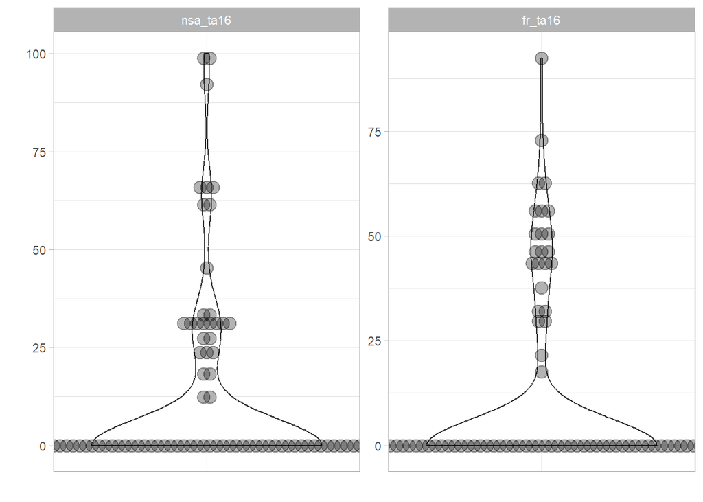

```r
plot_dist(GIRAI, dset = "Raw", iCodes = c("nsa_ta16", "fr_ta16"), type = "Violindot")
```

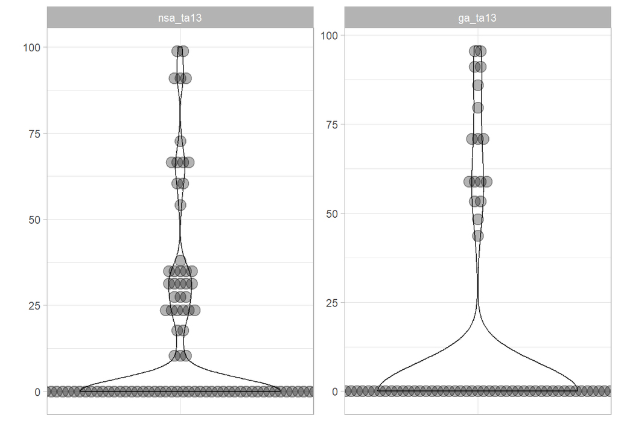

```r
plot_dist(GIRAI, dset = "Raw", iCodes = c("nsa_ta13", "ga_ta13"), type = "Violindot")
```

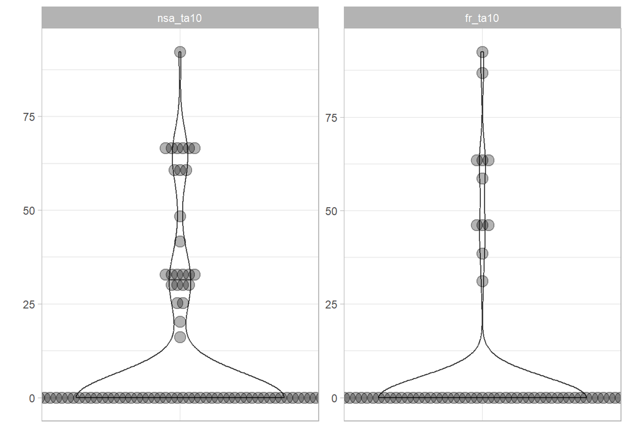

```r
plot_dist(GIRAI, dset = "Raw", iCodes = c("nsa_ta10", "fr_ta10"), type = "Violindot")
```

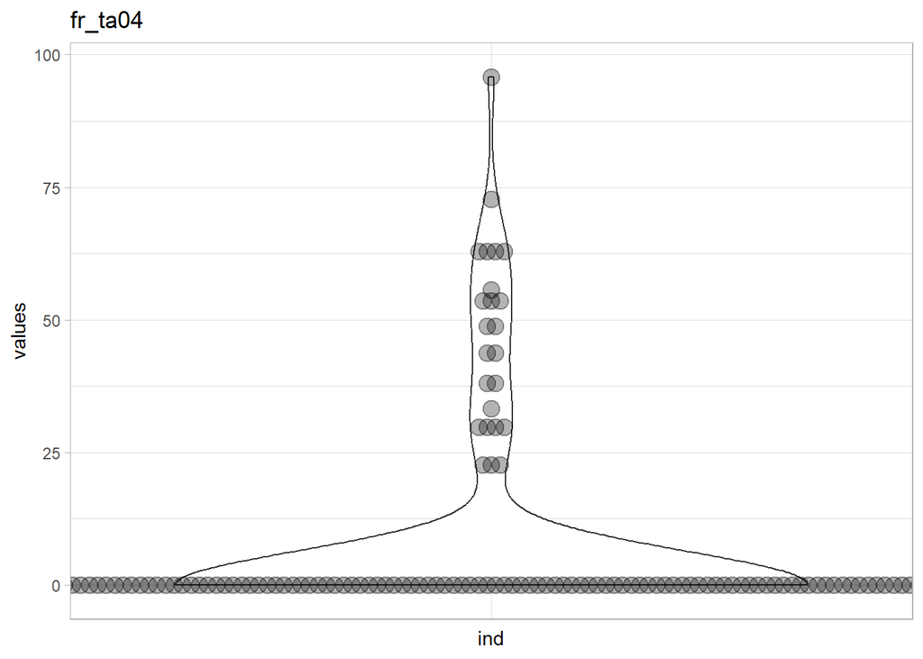

```r
plot_dist(GIRAI, dset = "Raw", iCodes = "fr_ta04", type = "Violindot")
```

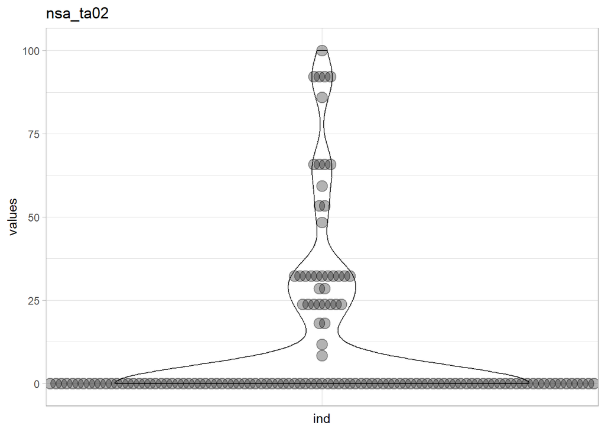

```r
plot_dist(GIRAI, dset = "Raw", iCodes = "nsa_ta02", type = "Violindot")
```

What were flagged as outliers seem to reflect the fact that only a few countries get a non-zero score in these indicators coming from these, apparently very emerging, thematic areas. This means that no treatment of the data would be necessary if *GIRAI* team decides that these thematic areas should be measured in spite of the abundance of zeros, that is, in spite of being *so* emergent. In an appendix we will perform such treatment for illustrative purposes only and for future reference of *GIRAI team* for other cases.

### Data aggregation and ranking

We can now aggregate the index to see the results, in terms of scores and in terms of ranks. We will use as aggregation formula the arithmetic weighted mean for all levels: 2 (indicators to pillars) and 3 (pillars to index). The weights for level 2 were stated to be all equal and for level 3 are 40% (*fr*), 40% (*ga*) and 20% (*nsa*). We will later, in an appendix, explore changing these weights.

```r
# Aggregate data set (Raw, which is already normalised)
GIRAI <- Aggregate(GIRAI, dset = "Raw", f_ag = "a_amean")
```

```
## Written data set to .$Data$Aggregated
```

```r
# get results table
GIRAI_results <- get_results(GIRAI, dset = "Aggregated", tab_type = "Full")

get_results(GIRAI, dset = "Aggregated", tab_type = "Full") |>
  reactable()
```

| uCode | Rank | index | fr | ga | nsa | fr_ta01 | fr_ta02 | fr_ta03 | fr_ta04 | fr_ta05 | fr_ta06 | fr_ta07 | fr_ta08 | fr_ta09 | fr_ta10 | fr_ta11 | fr_ta12 | fr_ta13 | fr_ta14 | fr_ta15 | fr_ta16 | fr_ta17 | fr_ta18 | fr_ta19 | ga_ta01 | ga_ta02 | ga_ta03 | ga_ta04 | ga_ta05 | … |
| --- | --- | --- | --- | --- | --- | --- | --- | --- | --- | --- | --- | --- | --- | --- | --- | --- | --- | --- | --- | --- | --- | --- | --- | --- | --- | --- | --- | --- | --- | --- |
| NLD | 1 | 86.16 | 74.33 | 95.46 | 91.23 | 64.19 | 96.29 | 96.29 | 64.19 | 0 | 0 | 64.19 | 96.29 | 96.29 | 64.19 | 96.29 | 96.29 | 96.29 | 96.29 | 96.29 | 0 | 96.29 | 96.29 | 96.29 | 96.99 | 96.99 | 96.99 | 96.99 | 87.29 | … |
| DEU | 2 | 82.77 | 72.69 | 93 | 82.48 | 31.39 | 94.16 | 94.16 | 31.39 | 62.78 | 94.16 | 62.78 | 94.16 | 0 | 0 | 94.16 | 94.16 | 94.16 | 94.16 | 94.16 | 62.78 | 94.16 | 94.16 | 94.16 | 93.99 | 93.99 | 93.99 | 93.99 | 93.99 | … |
| IRL | 3 | 74.98 | 81.71 | 74.17 | 63.16 | 63.36 | 95.05 | 95.05 | 63.36 | 63.36 | 95.05 | 63.36 | 95.05 | 95.05 | 63.36 | 95.05 | 95.05 | 95.05 | 95.05 | 95.05 | 0 | 95.05 | 95.05 | 95.05 | 95.22 | 95.22 | 95.22 | 95.22 | 95.22 | … |
| GBR | 4 | 73.12 | 60.66 | 80.9 | 82.48 | 62.3 | 62.3 | 93.46 | 0 | 62.3 | 0 | 0 | 93.46 | 0 | 31.15 | 93.46 | 93.46 | 62.3 | 93.46 | 62.3 | 62.3 | 93.46 | 93.46 | 93.46 | 92.04 | 92.04 | 92.04 | 82.84 | 92.04 | … |
| USA | 5 | 72.81 | 62.41 | 79.19 | 80.87 | 92.39 | 0 | 30.8 | 61.6 | 61.6 | 0 | 92.39 | 92.39 | 92.39 | 92.39 | 46.2 | 92.39 | 0 | 46.2 | 61.6 | 92.39 | 92.39 | 46.2 | 92.39 | 88.5 | 79.65 | 88.5 | 0 | 88.5 | … |
| EST | 6 | 67.61 | 65.58 | 81.52 | 43.86 | 0 | 93.46 | 93.46 | 0 | 62.3 | 93.46 | 62.3 | 93.46 | 93.46 | 0 | 93.46 | 93.46 | 93.46 | 93.46 | 93.46 | 0 | 93.46 | 93.46 | 0 | 83.47 | 92.75 | 92.75 | 83.47 | 92.75 | … |
| ITA | 7 | 61.8 | 59.99 | 55.96 | 77.1 | 48.51 | 72.76 | 72.76 | 48.51 | 48.51 | 72.76 | 48.51 | 72.76 | 72.76 | 0 | 72.76 | 72.76 | 72.76 | 72.76 | 72.76 | 0 | 72.76 | 72.76 | 72.76 | 75.94 | 75.94 | 75.94 | 0 | 75.94 | … |
| FRA | 8 | 57.62 | 56.23 | 58.92 | 57.81 | 0 | 89.03 | 89.03 | 0 | 0 | 0 | 0 | 89.03 | 89.03 | 0 | 89.03 | 89.03 | 89.03 | 89.03 | 89.03 | 0 | 89.03 | 89.03 | 89.03 | 79.33 | 0 | 88.15 | 79.33 | 0 | … |
| CAN | 9 | 57.39 | 37.8 | 80.84 | 49.68 | 95.75 | 0 | 0 | 95.75 | 0 | 47.88 | 0 | 95.75 | 0 | 0 | 95.75 | 95.75 | 0 | 95.75 | 0 | 0 | 0 | 95.75 | 0 | 85.86 | 85.86 | 85.86 | 95.4 | 85.86 | … |
| AUS | 10 | 56.22 | 34.69 | 72.44 | 66.82 | 64.31 | 32.15 | 64.31 | 64.31 | 0 | 48.23 | 64.31 | 0 | 0 | 0 | 0 | 96.46 | 0 | 48.23 | 32.15 | 0 | 48.23 | 48.23 | 48.23 | 95.58 | 95.58 | 95.58 | 95.58 | 86.02 | … |

[output cut: 128 more lines]

### Statistical qualities of aggregates (outputs)

Now that we actually aggregated the *index*, we can investigate the statistical properties of the aggregates: pillars and *index*.

Let us visualize the distribution of the pillars:

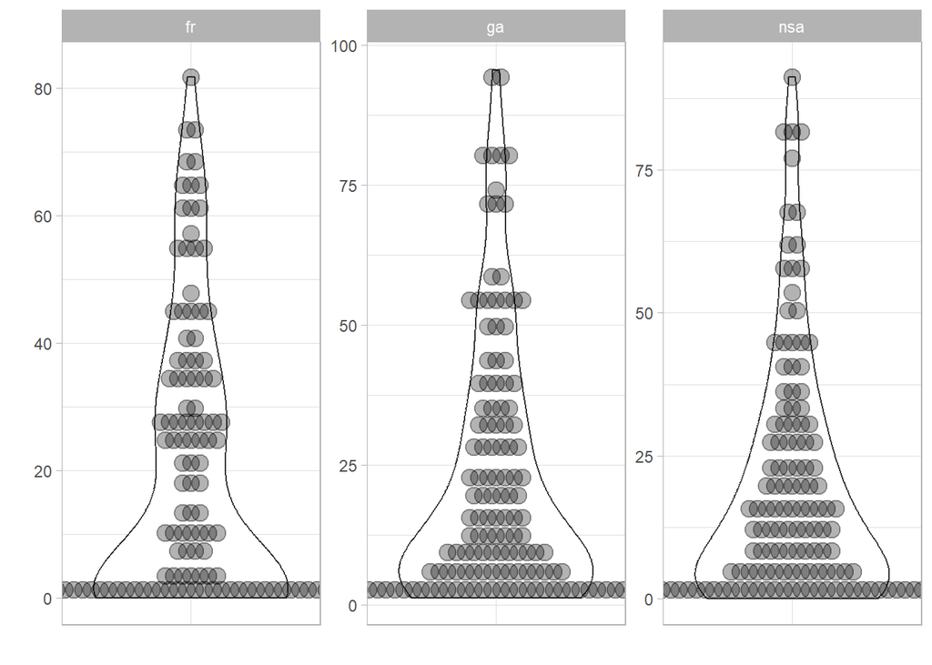

```r
# Plotting distribution for each pillar
iCodes_pillars <- c("fr", "ga", "nsa")
plot_dist(GIRAI, dset = "Aggregated", iCodes = iCodes_pillars, type = "Violindot")
```

Pillars are smoother than the indicators that compose them, even if they still have an important amount of zeroes. But this gets even more smoothed in the *index* and looks better-behaved:

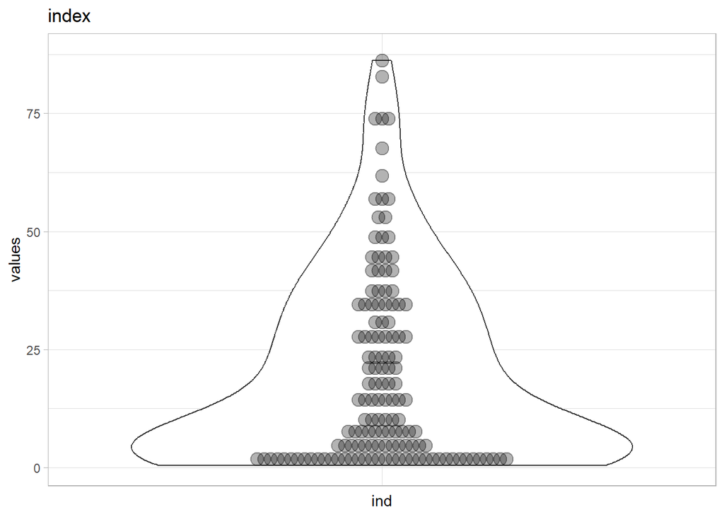

```r
# Plotting distribution for the index
plot_dist(GIRAI, dset = "Aggregated", iCodes = "index", type = "Violindot")
```

Then, the overall *index* and its constituent pillars seem to have good properties (better properties than the indicators, in particular), with values all across its range. All aggregates are smoother and unimodal at the bottom, which signals again to the emergent quality of the phenomena under observation. Let us check the statistics for the *Aggregated* dataframe (as we did before for *Raw*):

```r
# Get table of statistics for aggregated data
get_stats(GIRAI, dset = "Aggregated", out2 = "df") %>%
  # Select the last 4 rows (reverse order then select first 4)
  tail(n = 4) %>%
  reactable()
```

| iCode | Min | Max | Mean | Median | Std | Skew | Kurt | N.Avail | N.NonZero | N.Unique | N.Same | Frc.Avail | Frc.NonZero | Frc.Unique | Frc.Same | Flag.Avail | Flag.NonZero | Flag.Unique | Flag.SkewKurt |
| --- | --- | --- | --- | --- | --- | --- | --- | --- | --- | --- | --- | --- | --- | --- | --- | --- | --- | --- | --- |
| fr | 0 | 81.7 | 18 | 7.86 | 22 | 1.07 | 0.0465 | 138 | 85 | 86 | 53 | 1 | 0.616 | 0.623 | 0.384 | ok | ok | ok | ok |
| ga | 1.18 | 95.5 | 21.9 | 12 | 23.1 | 1.32 | 0.98 | 138 | 138 | 138 | 1 | 1 | 1 | 1 | 0.00725 | ok | ok | ok | ok |
| nsa | 0 | 91.2 | 19.1 | 12.1 | 21.2 | 1.42 | 1.51 | 138 | 121 | 121 | 17 | 1 | 0.877 | 0.877 | 0.123 | ok | ok | ok | ok |
| index | 0.474 | 86.2 | 19.8 | 12.1 | 20.4 | 1.18 | 0.801 | 138 | 138 | 138 | 1 | 1 | 1 | 1 | 0.00725 | ok | ok | ok | ok |

We can confirm that the *index* and the pillars have good properties since they show no flags of any kind, as most of the individual indicators did before. This means that the aggregation process was successful in producing much better and ultimately good enough statistical properties for the pillars and the index.

# Correlation analysis and statistical coherence

The assessment of statistical coherence involves a comprehensive analysis of indicator correlations across multiple levels. Correlation analysis serves as a vital tool for evaluating the degree to which observed data aligns with the underlying conceptual framework.

Within each level of the composite index, it is desirable to observe positive and statistically significant correlations among the constituent indicators. To gauge the strength of these correlations, the *Joint Research Centre-COIN* recommends the use of a correlation threshold of 0.3. When the correlation coefficient exceeds this threshold, it signifies a substantial shared variability between two elements, providing evidence of a significant relationship.

Furthermore, it is crucial to ensure that the framework avoids redundancy, which can manifest as excessively high correlations, typically at or above 0.9. Such high correlations indicate collinearity between two indicators, which could lead to issues like double counting and, consequently, an undue weighting of the same underlying phenomenon in the index. Fortunately, these correlation thresholds are seamlessly integrated into the COIN framework, facilitating a very systematic evaluation (and eventually automatable) of statistical coherence.

In the ensuing sections, we will present correlation analyses across various dimensions. This will encompass correlations among indicators within the same pillar, correlations between indicators and their aggregate levels (pillars and the overall index), correlations between individual pillars and the composite index and between the pillars themselves.

## Frameworks

Let us check the correlation structure of indicators within *Frameworks* pillar:

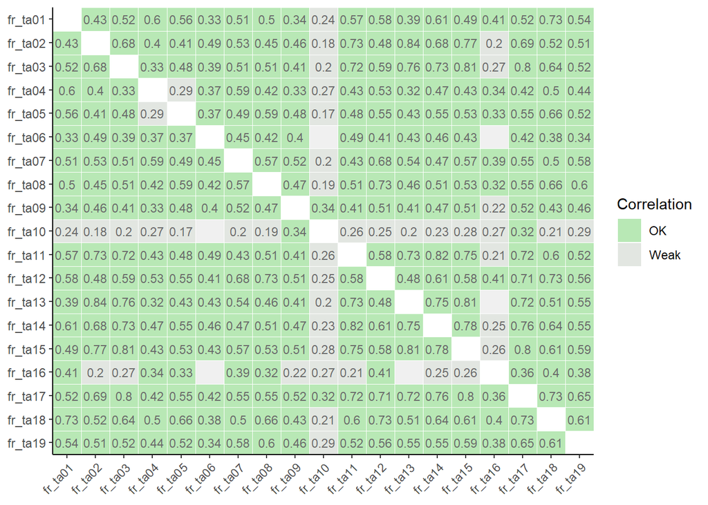

```r
plot_corr(GIRAI, dset = "Aggregated", iCodes = list("fr"), Levels = 1, flagcolours = TRUE)
```

Correlations in green are good enough, between 0.3 and 0.9, as mentioned before. When not shown, they are statistically insignificant and when shown but in gray, they are significant but lower than the threshold (0.3).

The general structure of correlations of this pillar is very good. *fr_ta_10* has 16 problematic (weak) correlations out of 18, which sets it quite apart from this pillar. *fr_ta_16* follows with 9. All the rest have 2 or less, which makes this pillar very sound anyway. Both indicators were flagged before, as possibly having outliers but having mostly a lot of zeroes.

Now, let us check the correlations of the indicators of *Frameworks* with the pillar and the index:

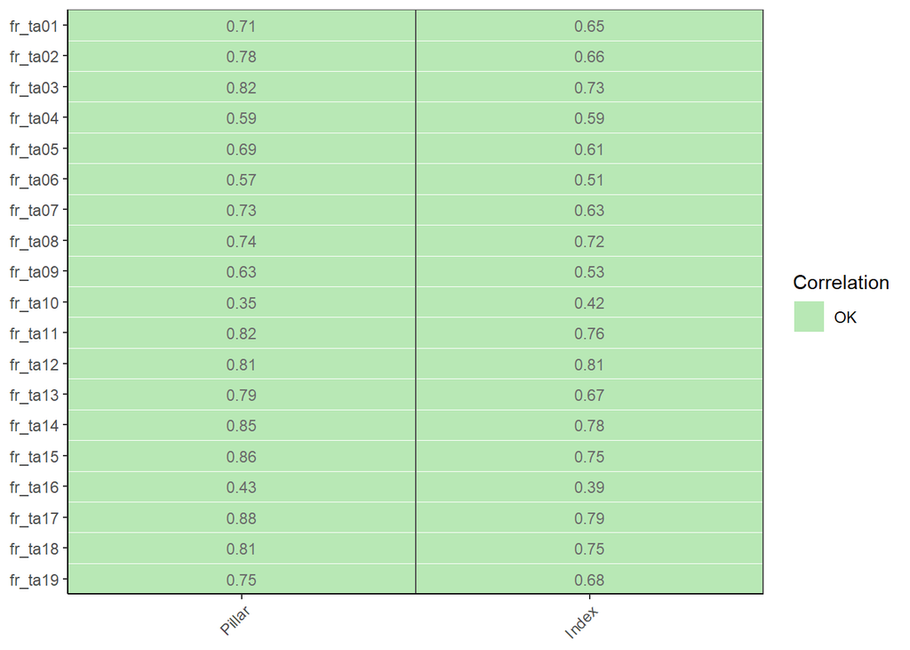

```r
plot_corr(GIRAI, dset = "Aggregated", iCodes = list("fr"), withparent = "family", flagcolours = T)
```

All the correlations of the indicators of *Frameworks* to the actual pillar and also to the *Index* are good, the lowest and closest to the lower threshold of correlation to its pillar being *fr_ta10* and *fr_ta16*, already flagged above.

## Government actions

Let us check the correlation structure of indicators within *Government actions* pillar:

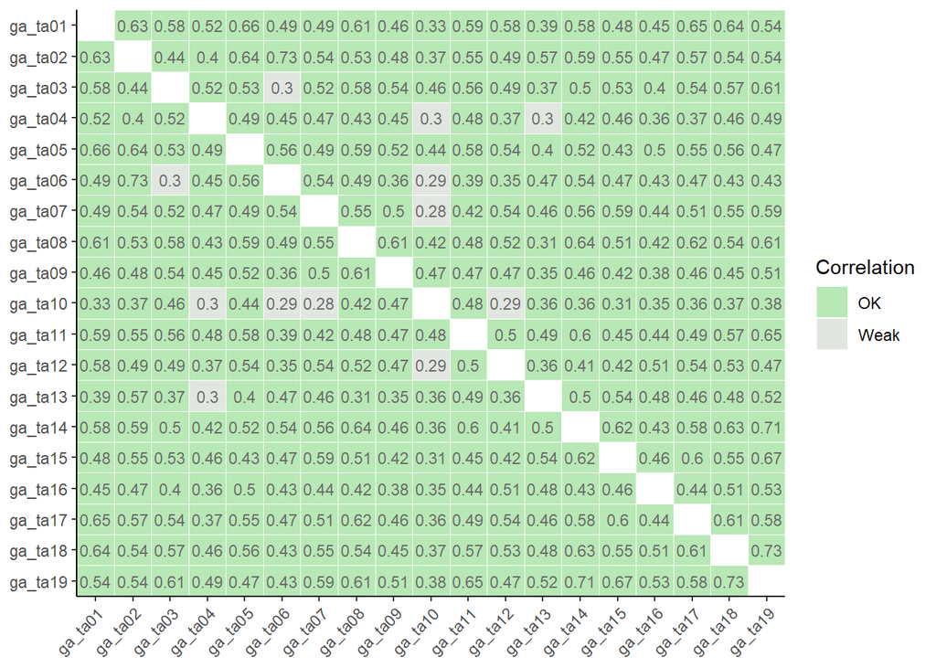

```r
plot_corr(GIRAI, dset = "Aggregated", iCodes = list("ga"), Levels = 1, flagcolours = TRUE)
```

This pillar very sound. *ga_ta10* has 4 (out of 18) correlations out of range, *ga_ta6* and *ga_ta4* have 2 and all the rest have one or none at all.

Now, let us check the correlations of the indicators of *Government actions* with the pillar and the *index*:

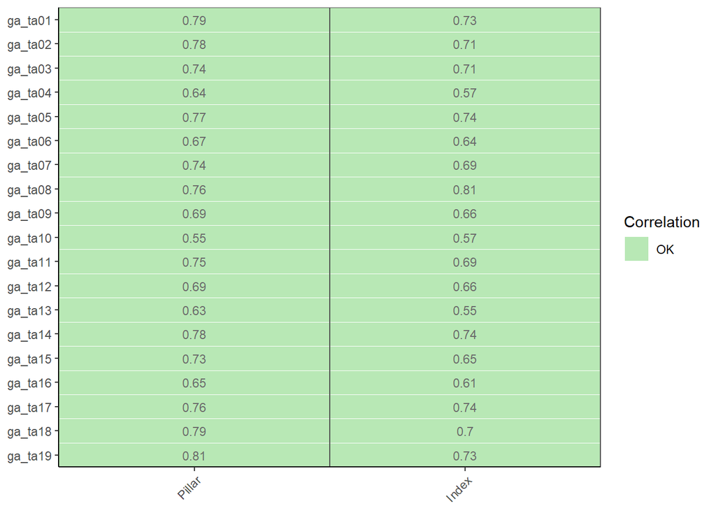

```r
plot_corr(GIRAI, dset = "Aggregated", iCodes = list("ga"), withparent = "family", flagcolours = T)
```

Again, all the correlations of the indicators of *Government actions* to the actual pillar and also to the *Index* are good. *ga_ta10*, flagged before, is the lowest but well above the threshold.

## Non-state actors

Let us check the correlation structure of indicators within *Non-state actors* pillar:

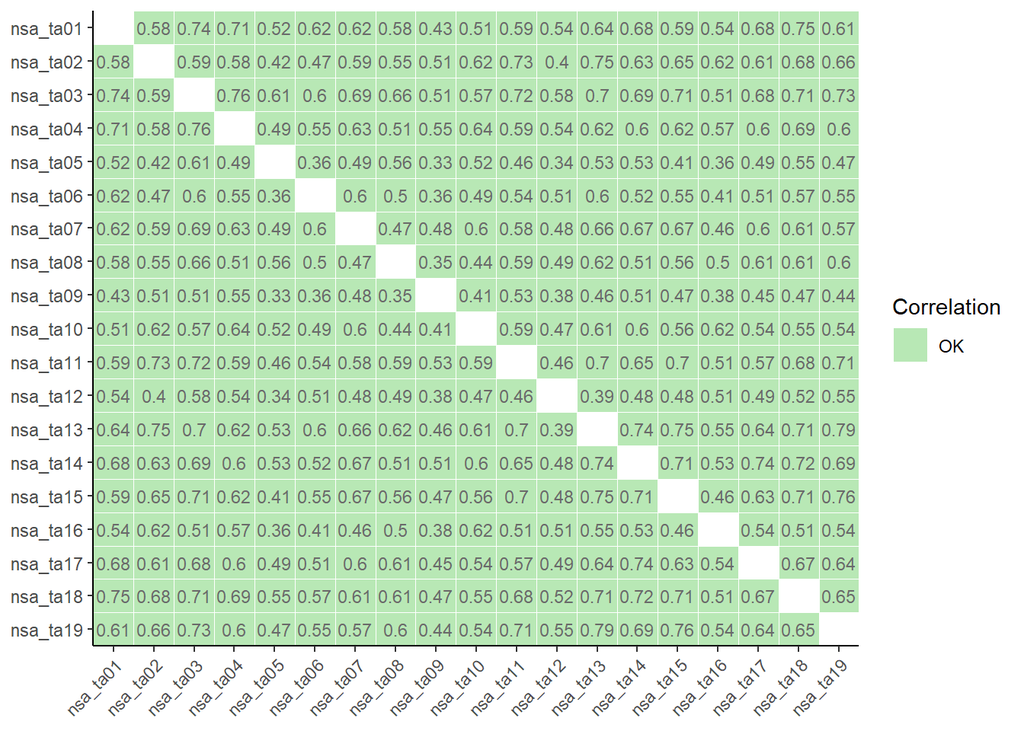

```r
plot_corr(GIRAI, dset = "Aggregated", iCodes = list("nsa"), grouplev = 2, flagcolours = TRUE)
```

This pillar is perfectly sound, with all correlations in appropriate ranges.

Now, let us check the correlations of the indicators of *Non-state actors* with the pillar and the *index*:

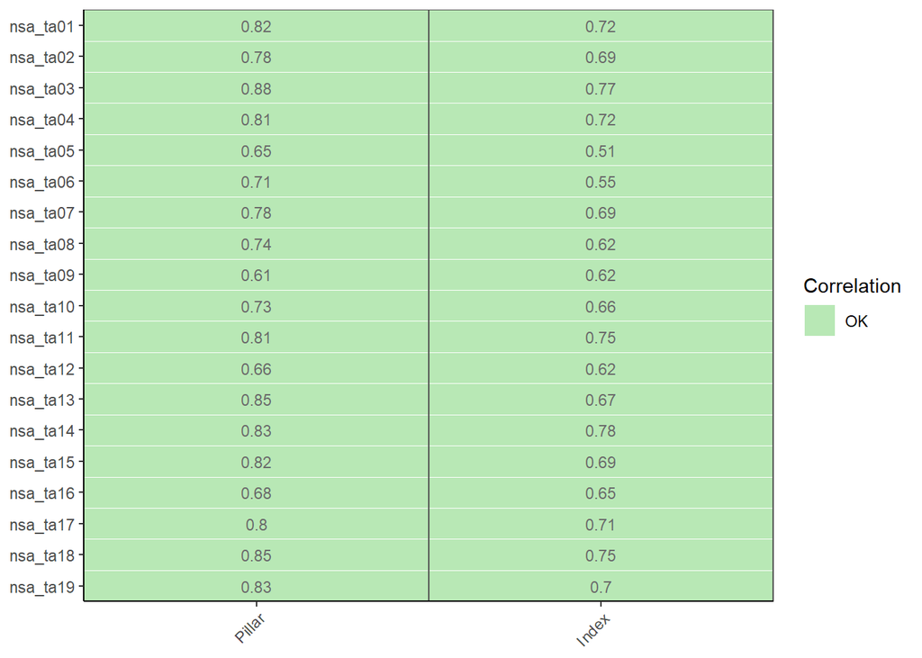

```r
plot_corr(GIRAI, dset = "Aggregated", iCodes = list("nsa"), withparent = "family", flagcolours = T)
```

As in the other cases, all the correlations of the indicators of *Non-state actors* to the actual pillar and also to the *Index* are good.

All in all, the correlation structure of indicators within pillars, as proof of the statistical coherence of the framework, is very good.

## Pillars among themselves

Let us check the correlation structure of the pillars. This level of aggregation holds utmost significance as it serves as a crucial test for the coherence and integrity of the overarching concept of the index:

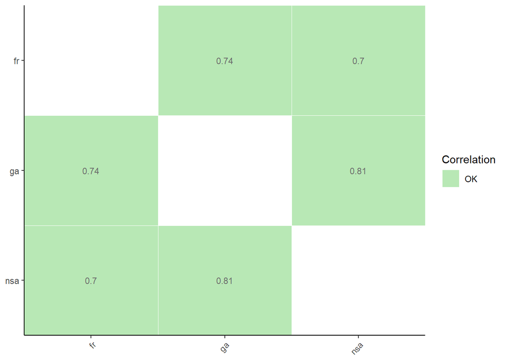

```r
plot_corr(GIRAI, dset = "Aggregated", Levels = 2, flagcolours = TRUE)
```

All correlations are in the desired ranges for the pillars, which shows strong support for the framework of the index.

## Pillars to index

Let us check the correlation between the pillars and the index:

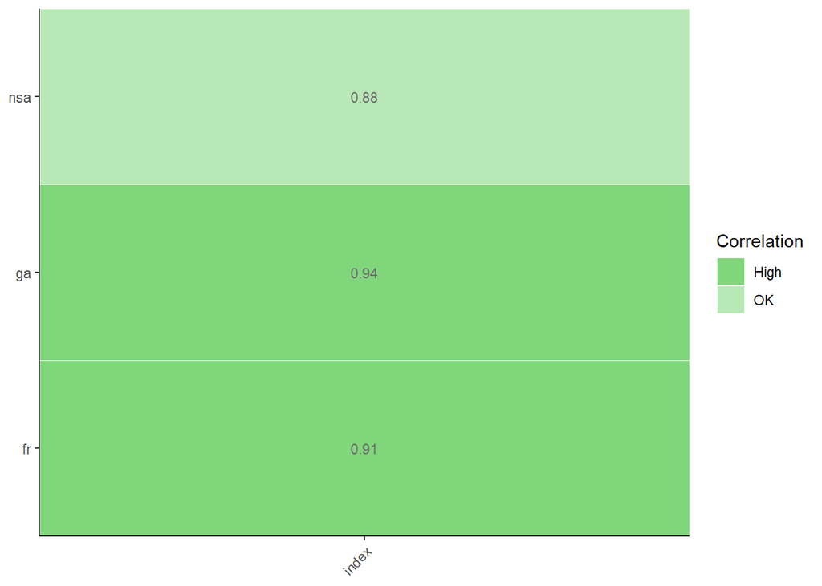

```r
plot_corr(GIRAI, dset = "Aggregated", Levels = c(2,3), flagcolours = TRUE)
```

*ga* and *fr* pillars have correlations to the index above the threshold of 0.9, signalling in principle some redundancy in the concept they measure in relation to the information brought by the index. The effectiveness correction seems to have worsened a little this particular structure of correlations (quite naturally. the separate pillar of secondary sources had the lowest correlation to the index before).

This might be difficult to overcome because in fact *all the three correlations* are quite high now. If we were to optimise weights (as will be done later) in order to have equal correlations to the index, this equal correlation will be also higher than 0.9, turning *all three correlations outside the proper range*. This result can be seen in other statistical audits without considering it a problem *per se*.

## Conclusions

The correlation structure within the indicators of each pillar, between the indicators and their respective pillars and *index*, within pillars, and between pillars and index is very good, adding substantial evidence to the soundness of the framework.

# Cronbach’s Alpha

Another alternative way to check the internal consistency of the indicators within each pillar and for the overall *index* is *Cronbach’s Alpha*. The coefficient ranges from 0 to 1, with higher values indicating greater internal consistency. A low *Alpha* (close to 0) suggests that the items in the scale do not consistently measure the same construct. This could be due to the inclusion of unrelated or contradictory items. A moderate *Alpha* (generally between 0.7 and 0.9, depending on the field) indicates some degree of internal consistency but leaves room for improvement. A high *Alpha* (close to 1) indicates strong internal consistency, implying that the items in the scale are highly correlated with each other and effectively measure the underlying construct. This is desirable when developing a reliable index.

For *Frameworks*:

```r
get_cronbach(GIRAI, dset = "Aggregated", iCodes = "fr", Level = 1) # Indicator level
```

```
## [1] 0.9497216
```

For *Government Actions*:

```r
get_cronbach(GIRAI, dset = "Aggregated", iCodes = "ga", Level = 1) # Indicator level
```

```
## [1] 0.9478158
```

For *Non-State Actors*:

```r
get_cronbach(GIRAI, dset = "Aggregated", iCodes = "nsa", Level = 1) # Indicator level
```

```
## [1] 0.9609769
```

For the overall *index*:

```r
get_cronbach(GIRAI, dset = "Aggregated", iCodes = "index", Level = 1) # Indicator level
```

```
## [1] 0.9781373
```

*Cronbach’s Alpha* is very high (close to 1) and similar for all pillars, adding evidence to the statistical soundness of each. The value at the level of the index, for all indicators, is even higher: the index effectively combining indicators from different pillars and measuring a broader, more nuanced concept. The individual pillars captures specific aspects, while the index assesses the overarching construct. This results, complementary to the correlation before and PCA analyses next, adds to the soundness of the framework.

# Principal Component Analysis

Continuing our exploration of statistical coherence, we delve into a principal component analysis (PCA). This analytical step serves to gauge the alignment between our conceptual framework and the empirical data. The overarching goal is to identify a single principal component capable of elucidating over 70% of the total variance (*European Comission, 2022*). Meeting these criteria signifies the existence of a unifying, one-dimensional phenomenon that underpins the various pillars. The same analysis will be performed at the level of indicators composing each of the pillars. In each of these levels, the objective is to assess the presence of a latent variable that the pillars of the index or the indicators of each pillar are supposed to be measuring.

By conducting PCA, we aim to distill the complex interplay of indicators into a more parsimonious representation, shedding light on the fundamental structure of our composite index. This not only enhances our understanding of the data but also bolsters the index’s credibility by corroborating its conceptual underpinnings through rigorous statistical analysis.

### Pillar level

Here we take the database formed by the pillars to check if there is a strong latent variable “behind” them.

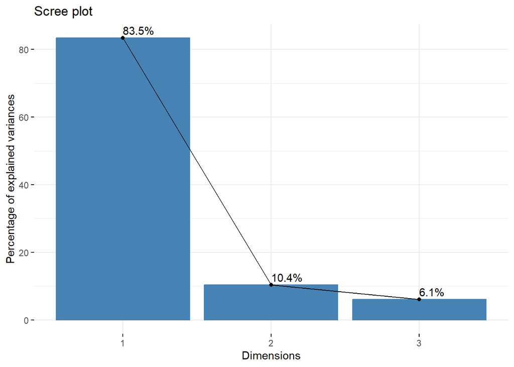

```r
# PCA
pillar_pca <- get_PCA(GIRAI, dset = "Aggregated", Level = 2, by_groups = FALSE, out2 = "list", nowarnings = FALSE)

fviz_eig(pillar_pca$PCAresults$All$PCAres, addlabels = TRUE)
```

Now, let us project the pillars in the space of the first 2 principal components (which, as we said, allows for a sufficient representation):

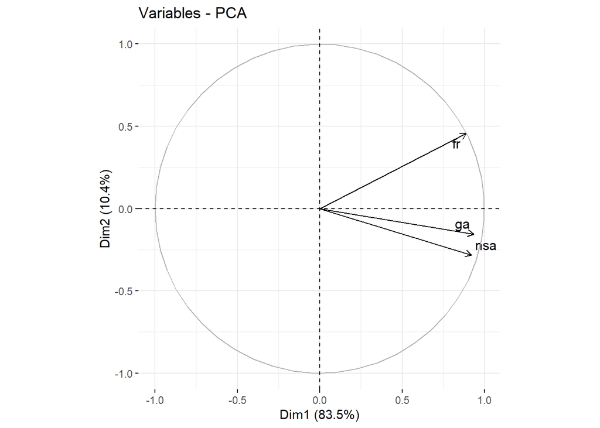

```r
fviz_pca_var(pillar_pca$PCAresults$All$PCAres, repel = TRUE)
```

Now let us explore the contributions of the pillars to each dimension:

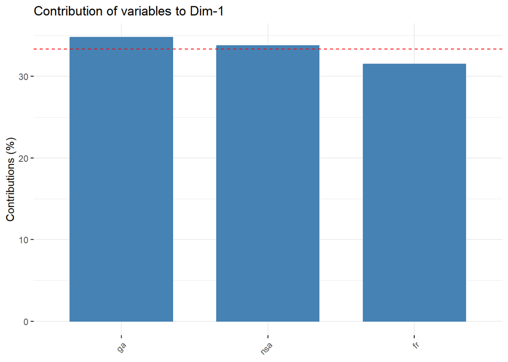

```r
fviz_contrib(pillar_pca$PCAresults$All$PCAres, choice = "var")
```

The red dashed line on the graph below indicates the expected average contribution of each pillar to the first dimension. If the contribution of the variables were uniform, the expected value would be 1/length(variables) = 1/3. For a given component, a variable with a contribution larger than this cutoff point could be considered as important in contributing to the component. *Frameworks* lies just a little below such threshold. The normalised version (constrained to sum to 1) of these contributions are called *PCA weights* and will be explored later to inform experimenting with a different set of weights.

Let us do the same with the second component:

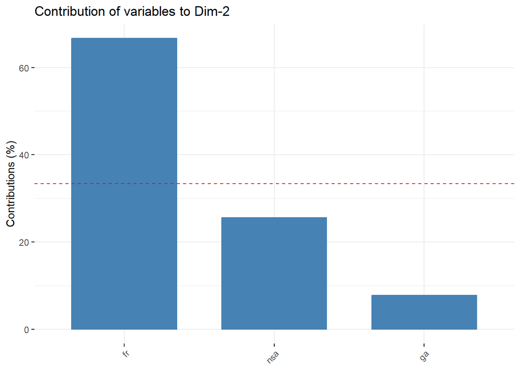

```r
fviz_contrib(pillar_pca$PCAresults$All$PCAres, choice = "var", axes = 2)
```

Turning to the factor loadings of the second component, which is less important than the first (by definition), the pattern indicates the presence of a second latent dimension in the data, one that is orthogonal or unrelated to the first; within this dimension, *fr* emerges as a particularly strong variable. Since the *index* is supposed to measure *one* latent variable related to *Responsible AI*, the pertinence of the second, less important and orthogonal dimension, should be put to the test. Nevertheless, *fr* has a significant loading to dimension 1 as well, which means that it also contributes significantly to the main latent dimension present in the data while also providing expression of some other aspects (presence in dimension 2). Also, the factor loading of *nsa* is quite significant to this second dimension too, and less so *ga*. Finally, this second dimensions accounts for a small proportion of the total variance of the dataset (10.4%).

### Indicators within pillars

Let us now perform PCA again but with the indicators conforming each pillar, to see if each pillar has a distinct latent dimension, in order to justify the existence of each pillar (and the grouping of indicators they imply) in the first place. We found that the index indeed references a large latent variable, now we turn our attention to each pillar. There are no standards as to how much is enough for the pillars, as in the 70% percent mentioned before for the index.

We will run the analysis for all the pillars at once and then analyze each in turn.

```r
ind_pillar_pca <- get_PCA(GIRAI, dset = "Aggregated", Level = 1, by_groups = TRUE, out2 = "list", nowarnings = FALSE)
```

#### Frameworks

Let us check the results of PCA on the indicators of *Frameworks* pillar:

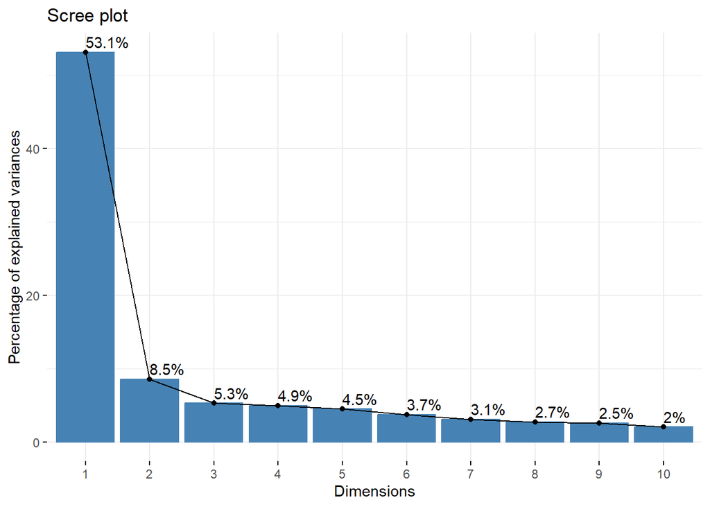

```r
fviz_eig(ind_pillar_pca$PCAresults$fr$PCAres, addlabels = TRUE)
```

The first component of the set of indicators in the *Frameworks* pillar accounts for 53.1% of the variance and the second for just 8.5%. Hence, there is a distinct latent variable behind the indicators of this pillar. The data doesn’t reject that there is one main dimension underlying the pillar, susceptible to be measured with this set of indicators.

A point of caution here: this doesn’t imply that this dimension is actually anything substantially enough like “Frameworks” to deserve that name, but it does say that the indicators of the pillars measure mainly (but certainly not exclusively) one dimension, which might or might not be anything like the concept “Frameworks” in the real world (which is something to be checked by other means). This, of course, applies to *all* our other findings of this kind.

#### Government actions

Let us check the results of PCA on the indicators of *Government actions* pillar:

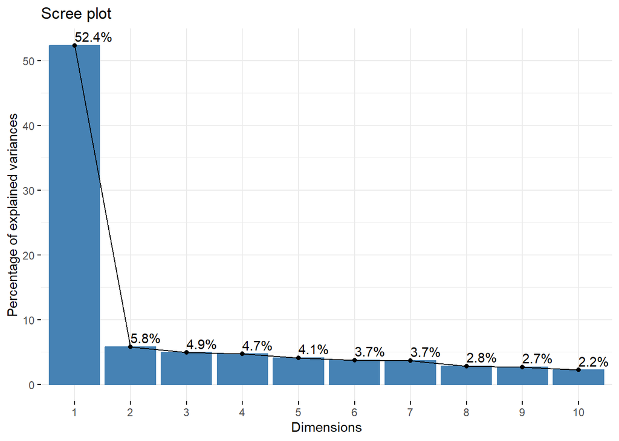

```r
fviz_eig(ind_pillar_pca$PCAresults$ga$PCAres, addlabels = TRUE)
```

52.4% for first component, distant second with 5.8%, making this pillar also quite sound in this respect.

#### Non-state actors

Let us check the results of PCA on the indicators of *Non-state actors* pillar:

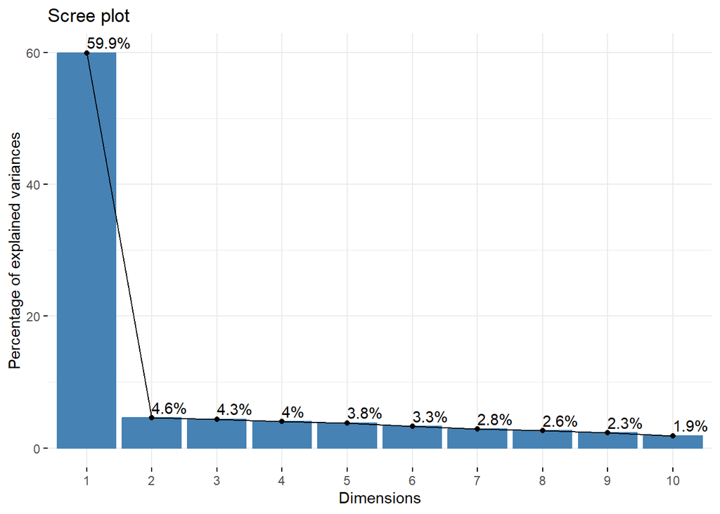

```r
fviz_eig(ind_pillar_pca$PCAresults$nsa$PCAres, addlabels = TRUE)
```

59.9% for first component, distant second with 4.6%, making this pillar sound as well.

### Conclusions

The pillars show the presence of a strong latent variable that accounts for a percentage of variance (83.5%) beyond the minimum threshold considered good practice (70%; *European Comission, 2022*), making the *index* very sound in this respect.

*Non-state actors* is the most sound pillar in these terms, followed by *Frameworks* and *Government Actions*. All pillars seem to have significant latent variables behind the indicators that conform each with distant second, in importance, dimensions, thus providing strong support to the framework.

# Leave-one-out analysis

How much are the ranking changed by removing individual indicators or pillars? One way of looking at indicator “importance” in a composite indicator is via correlations. A different way is to see what happens if we remove the indicator completely from the framework. If removing an indicator or a whole aggregation of indicators results in very little rank change, it is one indication that perhaps it is not necessary to include it.

## Pillars on Index

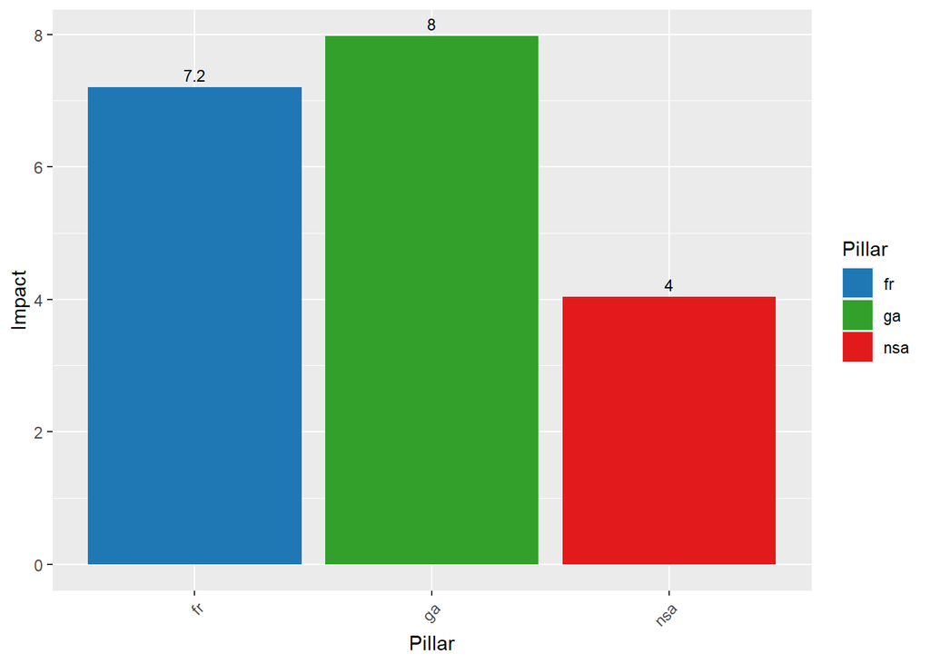

```r
pillar_loo <- remove_elements(GIRAI, Level = 2, dset = "Aggregated", iCode = "index", quietly = TRUE)

# Define a color palette with four distinct colors
colors <- c("#1f78b4", "#33a02c", "#e31a1c", "#ff7f00")

ggplot(data = data.frame(Pillar = names(pillar_loo$MeanAbsDiff[-1]),
                         Impact = pillar_loo$MeanAbsDiff[-1]),
       aes(x = Pillar, y = Impact, fill = Pillar)) +
  geom_bar(stat = "identity") +
  geom_text(aes(label = round(Impact, 1)), vjust = -0.5, color = "black", size = 3) +
  scale_fill_manual(values = colors) +  # Assign colors to the bars
  theme(axis.text.x = element_text(angle = 45, hjust = 1))
```

The impact of removing *ga* is the biggest (8) positions change in average), followed by *fr* with 7.2 and, last, *nsa* with 4.

## Indicators on Index

Let’s do the same exercise with the whole set of indicators:

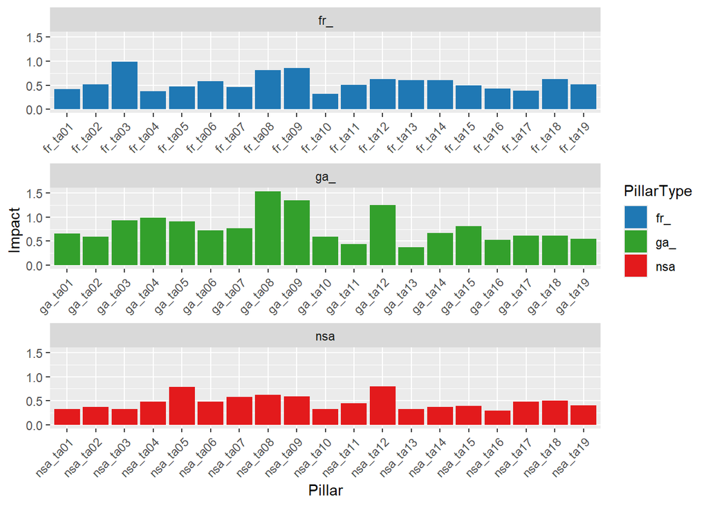

```r
ind_loo <- remove_elements(GIRAI, Level = 1, dset = "Aggregated", iCode = "index", quietly = TRUE)

# Define the colors
colors <- c("#1f78b4", "#33a02c", "#e31a1c", "#ff7f00")

# Create a data frame with an additional column for the Pillar Type
data <- data.frame(
  Pillar = names(ind_loo$MeanAbsDiff[-1]),
  Impact = ind_loo$MeanAbsDiff[-1],
  PillarType = substr(names(ind_loo$MeanAbsDiff[-1]), 1, 3)  # Extract first 3 characters as Pillar Type
)

# Plot with colors based on pillar type and facet by pillar type
ggplot(data = data, aes(x = Pillar, y = Impact, fill = PillarType)) +
  geom_bar(stat = "identity") +
  scale_fill_manual(values = colors) +  # Use predefined colors
  theme(axis.text.x = element_text(angle = 45, hjust = 1)) +
  facet_wrap(~ PillarType, scales = "free_x", ncol = 1)  # Create vertical facets
```

The impact of removing individual indicators ranges from a more than 1.5 positions change in average for *ga_ta08* and a little more than 0.3 for *nsa_ta16*. The impact is not too variable and quite low in general; no individual indicators dominate the ranking and the average change in results is always much lower than those of the pillars found before, respecting in this manner the hierarchy of the framework and thus supporting it.

# Uncertainty analysis

Statistical analysis of composite indicators often involves making assumptions that can influence how countries are ranked. Even with careful development, some level of uncertainty remains. To address this, we can compare results under different scenarios. Existing research suggests using *Monte Carlo* simulations and multiple modeling techniques to assess the robustness of an index (i.e., how sensitive it is to changes in assumptions).

The first step in this process is identifying which assumptions might have a significant impact on rankings. This involves considering the underlying data, indicator selection, and methodological choices (e.g., imputation methods, outlier treatment, normalization techniques, aggregation methods, weights). While we can’t test every assumption, focusing on some key area with plausible alternatives is a good starting point.

We will allow the weights to change 15% up or down in 1000 replications of the experiment, in order to see the intervals in which the scores and rankings move. These ranges for the weights include the PCA and optimised weights for each pillar, that calls for almost equal weighting of them all (1/3).

```r
# get nominal weights
w_nom <- GIRAI$Meta$Weights$Original

# build data frame specifying the levels to apply the noise at
noise_specs = data.frame(Level = 2,
                         NoiseFactor = 0.15)

# get 100 replications
noisy_wts <- get_noisy_weights(w = w_nom, noise_specs = noise_specs, Nrep = 1000)

# component of SA_specs for weights
l_weights <- list(Address = "$Log$Aggregate$w",
                  Distribution = noisy_wts,
                  Type = "discrete")

# create overall specification list
SA_specs <- list(
  Weights = l_weights
)

GIRAI$Log$Aggregate$w <- noisy_wts

set.seed(1)

UA_res <- get_sensitivity(GIRAI, SA_specs = SA_specs, N = 1000, SA_type = "UA",
                          dset = "Aggregated", iCode = "index", quietly = TRUE)
```

Let us see the results, for all countries, for top 10 and bottom 10.

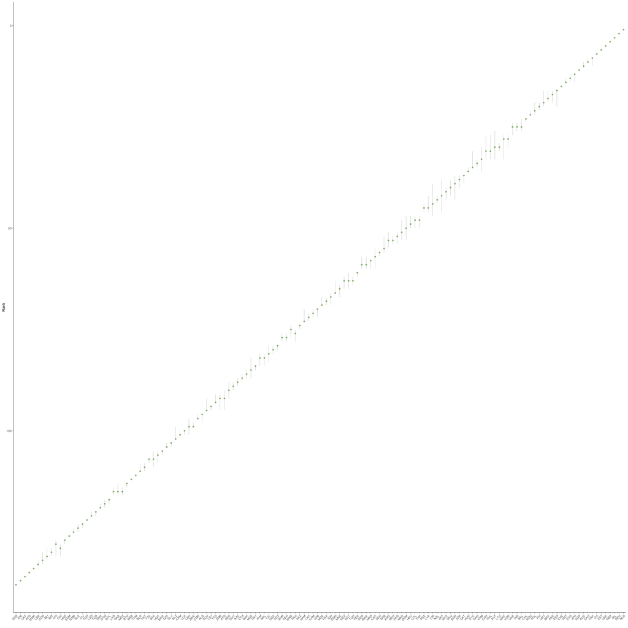

```r
plot_uncertainty(UA_res)
```

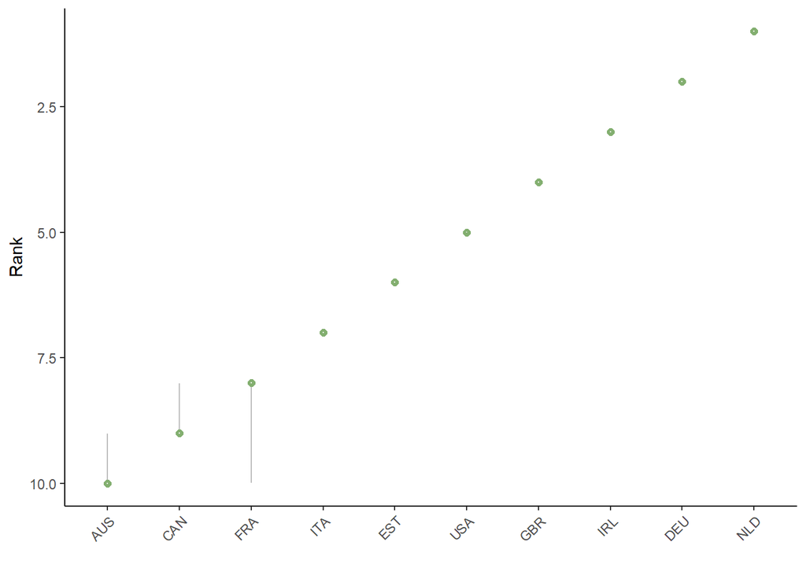

```r
plot_uncertainty(UA_res, plot_units = "top10")
```

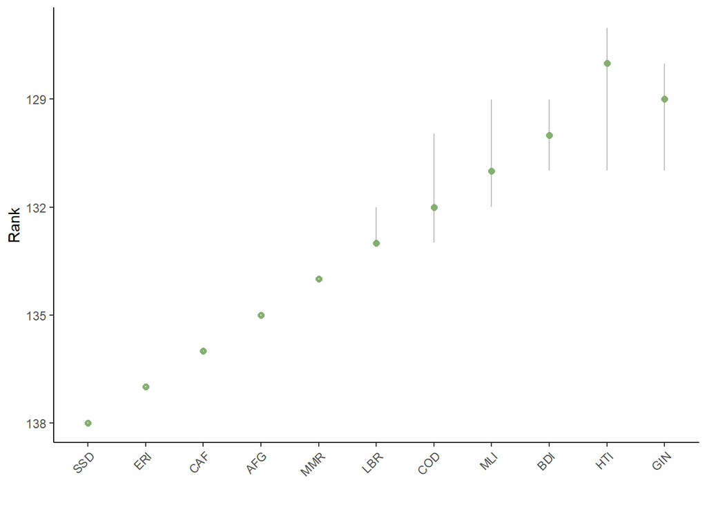

```r
plot_uncertainty(UA_res, plot_units = "bottom10")
```

This graph shows how countries are ranked based on their scores. It considers the median rank across multiple simulations where pillar weights were changed (representing uncertainty in the weighting scheme). The graph also highlights the spread of ranks by showing the 5th and 95th percentile values; we can see that these confidence intervals are not wide, showing that the big uncertainty about the appropriate weights that we introduced didn’t affect that confidence very much.

We focus on ranks in this uncertainty analysis because scores can vary significantly depending on the chosen methodology. Ranks provide a more consistent comparison across different ways of building a composite indicator. Even if scores differ, the relative order of units (their rank) might remain similar. Let us have one number to synthesize this argument:

```r
# Calculate the differences between Q95 and Q5
differences <- UA_res$RankStats$Q95 - UA_res$RankStats$Q5

# Calculate the mean of the differences
mean_difference <- mean(differences)

# Print the mean difference
print(mean_difference)
```

```
## [1] 2.342029
```

Adding noise to the pillar weights (+/- 15%), reflecting methodological uncertainty about their proper values, makes the interval between 5 and 95 percentiles to have a mean of more than two positions for the whole set of countries. If we consider the top 10 these intervals are smaller and for the first 7 positions they collapse to points.

That entails that if we take into account the uncertainty in the proper weights in this fashion, then only differences in rankings of more than two positions should be considered definite enough to separate them considering the whole ranking, whereas even smaller differences can be pointed out in the top 10.

# Appendixes

## Adjustment and comparisons

Even if the framework is sound as it is, for future reference of *GIRAI team* we will consider how the rankings would change when changing some aspects of the *GIRAI* methodology. In particular, we will consider:

1. Using a different set weights (equal weighting and a different set of unequal weights)
2. Using a geometric weighted mean instead of an arithmetic weighted mean (to introduce incomplete substitutability between the pillars, that is, considering them essentials of some sort)
3. Letting some indicators go

### Weights

Weights are used by most aggregation methods to optionally alter the contribution of each indicator in an aggregation group, as well as by aggregates themselves if they are further aggregated. Are the weights for the pillars stated previously “good” in some statistical sense?

#### PCA

We will inspect PCA results at a pillar level that we conducted before, to see the weights suggested by that procedure, normalising them (to constrain them to sum to 1) first:

```r
# Assuming pillar_pca$PCAresults$All$wts is your vector of weights
weights <- pillar_pca$PCAresults$All$wts

# Normalize the weights
normalized_weights <- weights / sum(weights)

# Now the normalized weights will sum to 1
normalized_weights
```

```
## [1] 0.3240030 0.3404447 0.3355522
```

Those are the normalised weights suggested by PCA for *fr*, *ga* and *nsa* respectively. They are almost equal.

#### Optimisation

Now we will perform another different procedure to get “good” weights. While PCA is based on linear algebra, another way to statistically weight indicators is via numerical optimisation. Optimisation is a numerical search method which finds a set of values which maximise or minimise some criterion, called the “objective function”.

```r
l_opt <- get_opt_weights(GIRAI, itarg = "equal", dset = "Aggregated",
Level = 2, out2 = "list")
```

```
## iterating... objective function = -10.0776590674977
```

```
## iterating... objective function = -10.6331906161101
```

```
## iterating... objective function = -9.74027927970573
```

```
## iterating... objective function = -9.89972969319927
```

```
## Optimisation successful!
```

```r
l_opt$WeightsOpt$Weight[58:60]
```

```
## [1] 0.3548387 0.3225806 0.3225806
```

Again, this procedure suggest almost equal weighting for *fr*, *ga* and *nsa*.

#### Equal weighting

Following the findings above, let us consider first equal weights for our simulation:

```r
# copy original weights
eq_wts <- GIRAI$Meta$Weights$Original

# Modify weights, make them sum to 1
eq_wts$Weight[eq_wts$iCode == "fr"] <- 0.33333334
eq_wts$Weight[eq_wts$iCode == "ga"] <- 0.33333333
eq_wts$Weight[eq_wts$iCode == "nsa"] <- 0.33333333

GIRAI_eq_wts <- GIRAI

# put weight set back with new name
GIRAI_eq_wts$Meta$Weights$eq_wts <- eq_wts

GIRAI_eq_wts <- Aggregate(GIRAI_eq_wts, dset = "Raw", f_ag = "a_amean", w = "eq_wts")
```

```
## Written data set to .$Data$Aggregated
```

```
## (overwritten existing data set)
```

```r
# get results table
GIRAI_eq_wts_results <- get_results(GIRAI_eq_wts, dset = "Aggregated", tab_type = "Full")

get_results(GIRAI_eq_wts, dset = "Aggregated", tab_type = "Full") |>
  reactable()
```

| uCode | Rank | index | fr | ga | nsa | fr_ta01 | fr_ta02 | fr_ta03 | fr_ta04 | fr_ta05 | fr_ta06 | fr_ta07 | fr_ta08 | fr_ta09 | fr_ta10 | fr_ta11 | fr_ta12 | fr_ta13 | fr_ta14 | fr_ta15 | fr_ta16 | fr_ta17 | fr_ta18 | fr_ta19 | ga_ta01 | ga_ta02 | ga_ta03 | ga_ta04 | ga_ta05 | … |
| --- | --- | --- | --- | --- | --- | --- | --- | --- | --- | --- | --- | --- | --- | --- | --- | --- | --- | --- | --- | --- | --- | --- | --- | --- | --- | --- | --- | --- | --- | --- |
| NLD | 1 | 87.01 | 74.33 | 95.46 | 91.23 | 64.19 | 96.29 | 96.29 | 64.19 | 0 | 0 | 64.19 | 96.29 | 96.29 | 64.19 | 96.29 | 96.29 | 96.29 | 96.29 | 96.29 | 0 | 96.29 | 96.29 | 96.29 | 96.99 | 96.99 | 96.99 | 96.99 | 87.29 | … |
| DEU | 2 | 82.72 | 72.69 | 93 | 82.48 | 31.39 | 94.16 | 94.16 | 31.39 | 62.78 | 94.16 | 62.78 | 94.16 | 0 | 0 | 94.16 | 94.16 | 94.16 | 94.16 | 94.16 | 62.78 | 94.16 | 94.16 | 94.16 | 93.99 | 93.99 | 93.99 | 93.99 | 93.99 | … |
| GBR | 3 | 74.68 | 60.66 | 80.9 | 82.48 | 62.3 | 62.3 | 93.46 | 0 | 62.3 | 0 | 0 | 93.46 | 0 | 31.15 | 93.46 | 93.46 | 62.3 | 93.46 | 62.3 | 62.3 | 93.46 | 93.46 | 93.46 | 92.04 | 92.04 | 92.04 | 82.84 | 92.04 | … |
| USA | 4 | 74.15 | 62.41 | 79.19 | 80.87 | 92.39 | 0 | 30.8 | 61.6 | 61.6 | 0 | 92.39 | 92.39 | 92.39 | 92.39 | 46.2 | 92.39 | 0 | 46.2 | 61.6 | 92.39 | 92.39 | 46.2 | 92.39 | 88.5 | 79.65 | 88.5 | 0 | 88.5 | … |
| IRL | 5 | 73.01 | 81.71 | 74.17 | 63.16 | 63.36 | 95.05 | 95.05 | 63.36 | 63.36 | 95.05 | 63.36 | 95.05 | 95.05 | 63.36 | 95.05 | 95.05 | 95.05 | 95.05 | 95.05 | 0 | 95.05 | 95.05 | 95.05 | 95.22 | 95.22 | 95.22 | 95.22 | 95.22 | … |
| ITA | 6 | 64.35 | 59.99 | 55.96 | 77.1 | 48.51 | 72.76 | 72.76 | 48.51 | 48.51 | 72.76 | 48.51 | 72.76 | 72.76 | 0 | 72.76 | 72.76 | 72.76 | 72.76 | 72.76 | 0 | 72.76 | 72.76 | 72.76 | 75.94 | 75.94 | 75.94 | 0 | 75.94 | … |
| EST | 7 | 63.65 | 65.58 | 81.52 | 43.86 | 0 | 93.46 | 93.46 | 0 | 62.3 | 93.46 | 62.3 | 93.46 | 93.46 | 0 | 93.46 | 93.46 | 93.46 | 93.46 | 93.46 | 0 | 93.46 | 93.46 | 0 | 83.47 | 92.75 | 92.75 | 83.47 | 92.75 | … |
| AUS | 8 | 57.98 | 34.69 | 72.44 | 66.82 | 64.31 | 32.15 | 64.31 | 64.31 | 0 | 48.23 | 64.31 | 0 | 0 | 0 | 0 | 96.46 | 0 | 48.23 | 32.15 | 0 | 48.23 | 48.23 | 48.23 | 95.58 | 95.58 | 95.58 | 95.58 | 86.02 | … |
| FRA | 9 | 57.66 | 56.23 | 58.92 | 57.81 | 0 | 89.03 | 89.03 | 0 | 0 | 0 | 0 | 89.03 | 89.03 | 0 | 89.03 | 89.03 | 89.03 | 89.03 | 89.03 | 0 | 89.03 | 89.03 | 89.03 | 79.33 | 0 | 88.15 | 79.33 | 0 | … |
| CAN | 10 | 56.11 | 37.8 | 80.84 | 49.68 | 95.75 | 0 | 0 | 95.75 | 0 | 47.88 | 0 | 95.75 | 0 | 0 | 95.75 | 95.75 | 0 | 95.75 | 0 | 0 | 0 | 95.75 | 0 | 85.86 | 85.86 | 85.86 | 95.4 | 85.86 | … |

[output cut: 128 more lines]

Let us compare both rankings:

```r
# compare index, sort by absolute rank difference
compare_coins(GIRAI, GIRAI_eq_wts, dset = "Aggregated", iCode = "index",
              sort_by = "Abs.diff", decreasing = TRUE) |>
  reactable::reactable()
```

| uCode | coin.1 | coin.2 | Diff | Abs.diff |
| --- | --- | --- | --- | --- |
| ZAF | 42 | 31 | 11 | 11 |
| GUY | 89 | 79 | 10 | 10 |
| ECU | 95 | 88 | 7 | 7 |
| PHL | 31 | 24 | 7 | 7 |
| THA | 47 | 54 | -7 | 7 |
| AUT | 30 | 36 | -6 | 6 |
| BGR | 39 | 33 | 6 | 6 |
| LBN | 99 | 93 | 6 | 6 |
| MNE | 65 | 59 | 6 | 6 |
| TJK | 81 | 87 | -6 | 6 |

[output cut: 128 more lines]

*South Africa* moves up 11 positions, *Canada* goes down one position and *China* does not move.

```r
compare_coins(GIRAI, GIRAI_eq_wts, dset = "Aggregated", iCode = "index",
              sort_by = "Abs.diff", decreasing = TRUE) %>%
        summarise(mean_abs_diff = mean(Abs.diff))
```

```
##   mean_abs_diff
## 1      2.478261
```

The mean absolute difference is 2.47 positions in the ranking when adjusting weights in order to be equal.

#### Another set of unequal weights

We can experiment changing manually the weights:

```r
# copy original weights
uneq_wts <- GIRAI$Meta$Weights$Original

# Assign new weights
uneq_wts$Weight[uneq_wts$iCode == "fr"] <- 0.45
uneq_wts$Weight[uneq_wts$iCode == "ga"] <- 0.35
uneq_wts$Weight[uneq_wts$iCode == "nsa"] <- 0.20

GIRAI_uneq_wts <- GIRAI

# put weight set back with new name
GIRAI_uneq_wts$Meta$Weights$uneq_wts <- uneq_wts

GIRAI_uneq_wts <- Aggregate(GIRAI_uneq_wts, dset = "Raw", f_ag = "a_amean", w = "uneq_wts")
```

```
## Written data set to .$Data$Aggregated
```

```
## (overwritten existing data set)
```

```r
# get results table
GIRAI_uneq_wts_results <- get_results(GIRAI_uneq_wts, dset = "Aggregated", tab_type = "Full")

get_results(GIRAI_uneq_wts, dset = "Aggregated", tab_type = "Full") |>
  reactable()
```

| uCode | Rank | index | fr | ga | nsa | fr_ta01 | fr_ta02 | fr_ta03 | fr_ta04 | fr_ta05 | fr_ta06 | fr_ta07 | fr_ta08 | fr_ta09 | fr_ta10 | fr_ta11 | fr_ta12 | fr_ta13 | fr_ta14 | fr_ta15 | fr_ta16 | fr_ta17 | fr_ta18 | fr_ta19 | ga_ta01 | ga_ta02 | ga_ta03 | ga_ta04 | ga_ta05 | … |
| --- | --- | --- | --- | --- | --- | --- | --- | --- | --- | --- | --- | --- | --- | --- | --- | --- | --- | --- | --- | --- | --- | --- | --- | --- | --- | --- | --- | --- | --- | --- |
| NLD | 1 | 85.1 | 74.33 | 95.46 | 91.23 | 64.19 | 96.29 | 96.29 | 64.19 | 0 | 0 | 64.19 | 96.29 | 96.29 | 64.19 | 96.29 | 96.29 | 96.29 | 96.29 | 96.29 | 0 | 96.29 | 96.29 | 96.29 | 96.99 | 96.99 | 96.99 | 96.99 | 87.29 | … |
| DEU | 2 | 81.75 | 72.69 | 93 | 82.48 | 31.39 | 94.16 | 94.16 | 31.39 | 62.78 | 94.16 | 62.78 | 94.16 | 0 | 0 | 94.16 | 94.16 | 94.16 | 94.16 | 94.16 | 62.78 | 94.16 | 94.16 | 94.16 | 93.99 | 93.99 | 93.99 | 93.99 | 93.99 | … |
| IRL | 3 | 75.36 | 81.71 | 74.17 | 63.16 | 63.36 | 95.05 | 95.05 | 63.36 | 63.36 | 95.05 | 63.36 | 95.05 | 95.05 | 63.36 | 95.05 | 95.05 | 95.05 | 95.05 | 95.05 | 0 | 95.05 | 95.05 | 95.05 | 95.22 | 95.22 | 95.22 | 95.22 | 95.22 | … |
| GBR | 4 | 72.11 | 60.66 | 80.9 | 82.48 | 62.3 | 62.3 | 93.46 | 0 | 62.3 | 0 | 0 | 93.46 | 0 | 31.15 | 93.46 | 93.46 | 62.3 | 93.46 | 62.3 | 62.3 | 93.46 | 93.46 | 93.46 | 92.04 | 92.04 | 92.04 | 82.84 | 92.04 | … |
| USA | 5 | 71.97 | 62.41 | 79.19 | 80.87 | 92.39 | 0 | 30.8 | 61.6 | 61.6 | 0 | 92.39 | 92.39 | 92.39 | 92.39 | 46.2 | 92.39 | 0 | 46.2 | 61.6 | 92.39 | 92.39 | 46.2 | 92.39 | 88.5 | 79.65 | 88.5 | 0 | 88.5 | … |
| EST | 6 | 66.82 | 65.58 | 81.52 | 43.86 | 0 | 93.46 | 93.46 | 0 | 62.3 | 93.46 | 62.3 | 93.46 | 93.46 | 0 | 93.46 | 93.46 | 93.46 | 93.46 | 93.46 | 0 | 93.46 | 93.46 | 0 | 83.47 | 92.75 | 92.75 | 83.47 | 92.75 | … |
| ITA | 7 | 62 | 59.99 | 55.96 | 77.1 | 48.51 | 72.76 | 72.76 | 48.51 | 48.51 | 72.76 | 48.51 | 72.76 | 72.76 | 0 | 72.76 | 72.76 | 72.76 | 72.76 | 72.76 | 0 | 72.76 | 72.76 | 72.76 | 75.94 | 75.94 | 75.94 | 0 | 75.94 | … |
| FRA | 8 | 57.49 | 56.23 | 58.92 | 57.81 | 0 | 89.03 | 89.03 | 0 | 0 | 0 | 0 | 89.03 | 89.03 | 0 | 89.03 | 89.03 | 89.03 | 89.03 | 89.03 | 0 | 89.03 | 89.03 | 89.03 | 79.33 | 0 | 88.15 | 79.33 | 0 | … |
| CAN | 9 | 55.24 | 37.8 | 80.84 | 49.68 | 95.75 | 0 | 0 | 95.75 | 0 | 47.88 | 0 | 95.75 | 0 | 0 | 95.75 | 95.75 | 0 | 95.75 | 0 | 0 | 0 | 95.75 | 0 | 85.86 | 85.86 | 85.86 | 95.4 | 85.86 | … |
| AUS | 10 | 54.33 | 34.69 | 72.44 | 66.82 | 64.31 | 32.15 | 64.31 | 64.31 | 0 | 48.23 | 64.31 | 0 | 0 | 0 | 0 | 96.46 | 0 | 48.23 | 32.15 | 0 | 48.23 | 48.23 | 48.23 | 95.58 | 95.58 | 95.58 | 95.58 | 86.02 | … |

[output cut: 128 more lines]

Let us compare the ranking resulting from these unequal weights compared to our benchmark (*statu quo*):

```r
# compare index, sort by absolute rank difference
compare_coins(GIRAI, GIRAI_uneq_wts, dset = "Aggregated", iCode = "index",
              sort_by = "Abs.diff", decreasing = TRUE) |>
  reactable::reactable()
```

| uCode | coin.1 | coin.2 | Diff | Abs.diff |
| --- | --- | --- | --- | --- |
| CRI | 44 | 49 | -5 | 5 |
| DOM | 50 | 46 | 4 | 4 |
| LVA | 45 | 41 | 4 | 4 |
| SRB | 55 | 51 | 4 | 4 |
| SVK | 35 | 31 | 4 | 4 |
| ATG | 91 | 94 | -3 | 3 |
| GIN | 128 | 131 | -3 | 3 |
| GRC | 28 | 25 | 3 | 3 |
| KOR | 27 | 30 | -3 | 3 |
| KWT | 57 | 60 | -3 | 3 |

[output cut: 128 more lines]

*Costa Rica* goes down 5 positions. *Canada* stays the same and *China* goes down one.

```r
compare_coins(GIRAI, GIRAI_uneq_wts, dset = "Aggregated", iCode = "index",
              sort_by = "Abs.diff", decreasing = TRUE) |>
    summarise(mean_abs_diff = mean(Abs.diff))
```

```
##   mean_abs_diff
## 1      1.043478
```

The mean absolute difference is 1.04 positions in the ranking when choosing another set of unequal weights.

### Aggregation formula

We will explore the impact of using a *geometric weighted mean* to aggregate the pillars instead of the arithmetic weighted mean employed so far (indicators are aggregated, as before, with an arithmetic weighted mean). Geometric means don’t accept zeroes, so we will add the smallest quantity possible to all zero values in our modified custom function.

```r
# Make a copy
GIRAI_geom <- GIRAI

# Custom weighted geometric mean
weighted_geo_mean_modified <- function(x, w, small_value = 0.000001) {
  # Add a small value to zero elements
  x[x == 0] <- small_value

  # Calculate the weighted geometric mean using a_gmean from coinr
  result <- a_gmean(x, w)

  return(result)
}

GIRAI_geom <- Aggregate(GIRAI_geom, dset = "Raw", f_ag = c("a_amean", "weighted_geo_mean_modified"))
```

```
## Written data set to .$Data$Aggregated
```

```
## (overwritten existing data set)
```

```r
# Get results table
GIRAI_geom_results <- get_results(GIRAI_geom, dset = "Aggregated", tab_type = "Full")

get_results(GIRAI_geom, dset = "Aggregated", tab_type = "Full") |>
  reactable()
```

| uCode | Rank | index | fr | ga | nsa | fr_ta01 | fr_ta02 | fr_ta03 | fr_ta04 | fr_ta05 | fr_ta06 | fr_ta07 | fr_ta08 | fr_ta09 | fr_ta10 | fr_ta11 | fr_ta12 | fr_ta13 | fr_ta14 | fr_ta15 | fr_ta16 | fr_ta17 | fr_ta18 | fr_ta19 | ga_ta01 | ga_ta02 | ga_ta03 | ga_ta04 | ga_ta05 | … |
| --- | --- | --- | --- | --- | --- | --- | --- | --- | --- | --- | --- | --- | --- | --- | --- | --- | --- | --- | --- | --- | --- | --- | --- | --- | --- | --- | --- | --- | --- | --- |
| NLD | 1 | 85.59 | 74.33 | 95.46 | 91.23 | 64.19 | 96.29 | 96.29 | 64.19 | 0 | 0 | 64.19 | 96.29 | 96.29 | 64.19 | 96.29 | 96.29 | 96.29 | 96.29 | 96.29 | 0 | 96.29 | 96.29 | 96.29 | 96.99 | 96.99 | 96.99 | 96.99 | 87.29 | … |
| DEU | 2 | 82.27 | 72.69 | 93 | 82.48 | 31.39 | 94.16 | 94.16 | 31.39 | 62.78 | 94.16 | 62.78 | 94.16 | 0 | 0 | 94.16 | 94.16 | 94.16 | 94.16 | 94.16 | 62.78 | 94.16 | 94.16 | 94.16 | 93.99 | 93.99 | 93.99 | 93.99 | 93.99 | … |
| IRL | 3 | 74.66 | 81.71 | 74.17 | 63.16 | 63.36 | 95.05 | 95.05 | 63.36 | 63.36 | 95.05 | 63.36 | 95.05 | 95.05 | 63.36 | 95.05 | 95.05 | 95.05 | 95.05 | 95.05 | 0 | 95.05 | 95.05 | 95.05 | 95.22 | 95.22 | 95.22 | 95.22 | 95.22 | … |
| GBR | 4 | 72.38 | 60.66 | 80.9 | 82.48 | 62.3 | 62.3 | 93.46 | 0 | 62.3 | 0 | 0 | 93.46 | 0 | 31.15 | 93.46 | 93.46 | 62.3 | 93.46 | 62.3 | 62.3 | 93.46 | 93.46 | 93.46 | 92.04 | 92.04 | 92.04 | 82.84 | 92.04 | … |
| USA | 5 | 72.29 | 62.41 | 79.19 | 80.87 | 92.39 | 0 | 30.8 | 61.6 | 61.6 | 0 | 92.39 | 92.39 | 92.39 | 92.39 | 46.2 | 92.39 | 0 | 46.2 | 61.6 | 92.39 | 92.39 | 46.2 | 92.39 | 88.5 | 79.65 | 88.5 | 0 | 88.5 | … |
| EST | 6 | 66.01 | 65.58 | 81.52 | 43.86 | 0 | 93.46 | 93.46 | 0 | 62.3 | 93.46 | 62.3 | 93.46 | 93.46 | 0 | 93.46 | 93.46 | 93.46 | 93.46 | 93.46 | 0 | 93.46 | 93.46 | 0 | 83.47 | 92.75 | 92.75 | 83.47 | 92.75 | … |
| ITA | 7 | 61.35 | 59.99 | 55.96 | 77.1 | 48.51 | 72.76 | 72.76 | 48.51 | 48.51 | 72.76 | 48.51 | 72.76 | 72.76 | 0 | 72.76 | 72.76 | 72.76 | 72.76 | 72.76 | 0 | 72.76 | 72.76 | 72.76 | 75.94 | 75.94 | 75.94 | 0 | 75.94 | … |
| FRA | 8 | 57.61 | 56.23 | 58.92 | 57.81 | 0 | 89.03 | 89.03 | 0 | 0 | 0 | 0 | 89.03 | 89.03 | 0 | 89.03 | 89.03 | 89.03 | 89.03 | 89.03 | 0 | 89.03 | 89.03 | 89.03 | 79.33 | 0 | 88.15 | 79.33 | 0 | … |
| CAN | 9 | 54.11 | 37.8 | 80.84 | 49.68 | 95.75 | 0 | 0 | 95.75 | 0 | 47.88 | 0 | 95.75 | 0 | 0 | 95.75 | 95.75 | 0 | 95.75 | 0 | 0 | 0 | 95.75 | 0 | 85.86 | 85.86 | 85.86 | 95.4 | 85.86 | … |
| AUS | 10 | 53.1 | 34.69 | 72.44 | 66.82 | 64.31 | 32.15 | 64.31 | 64.31 | 0 | 48.23 | 64.31 | 0 | 0 | 0 | 0 | 96.46 | 0 | 48.23 | 32.15 | 0 | 48.23 | 48.23 | 48.23 | 95.58 | 95.58 | 95.58 | 95.58 | 86.02 | … |

[output cut: 128 more lines]

Let us compare the rankings:

```r
# compare index, sort by absolute rank difference
compare_coins(GIRAI, GIRAI_geom, dset = "Aggregated", iCode = "index",
              sort_by = "Abs.diff", decreasing = TRUE) |>
  reactable::reactable()
```

| uCode | coin.1 | coin.2 | Diff | Abs.diff |
| --- | --- | --- | --- | --- |
| CRI | 44 | 86 | -42 | 42 |
| GAB | 115 | 85 | 30 | 30 |
| KWT | 57 | 87 | -30 | 30 |
| BFA | 107 | 84 | 23 | 23 |
| MNE | 65 | 88 | -23 | 23 |
| BLZ | 102 | 123 | -21 | 21 |
| PAN | 75 | 96 | -21 | 21 |
| SLV | 103 | 82 | 21 | 21 |
| MDA | 69 | 89 | -20 | 20 |
| ZWE | 98 | 80 | 18 | 18 |

[output cut: 128 more lines]

*Costa Rica* goes down 42 positions, *Canada* and *China* stay the same.

```r
compare_coins(GIRAI, GIRAI_geom, dset = "Aggregated", iCode = "index",
              sort_by = "Abs.diff", decreasing = TRUE) |>
    summarise(mean_abs_diff = mean(Abs.diff))
```

```
##   mean_abs_diff
## 1      5.144928
```

The mean absolute difference is 5.14 positions in the ranking when choosing geometric mean as the aggregation formula for pillars.

### Removing indicators

Even if there are not indicators to seriously consider excluding, we can try excluding *fr_ta10*, *ga_ta10* and *nsa_ta10* for illustration of how this feature works. The first two have some problematic correlations with their respective pillar companions and the third should also be removed since it is the whole thematic area that needs to be excluded at once for symmetry.

```r
# Create new COIN
GIRAI_remove <- new_coin(
                        iData,
                        iMeta,
                        exclude = c("fr_ta10", "ga_ta10", "nsa_ta10"),
)
```

```
## iData checked and OK.
```

```
## iMeta checked and OK.
```

```
## Written data set to .$Data$Raw
```

```r
GIRAI_remove <- Aggregate(GIRAI_remove, dset = "Raw")
```

```
## Written data set to .$Data$Aggregated
```

```r
# get results table
GIRAI_remove_results <- get_results(GIRAI_remove, dset = "Aggregated", tab_type = "Full")

get_results(GIRAI_remove, dset = "Aggregated", tab_type = "Full") |>
  reactable()
```

| uCode | Rank | index | fr | ga | nsa | fr_ta01 | fr_ta02 | fr_ta03 | fr_ta04 | fr_ta05 | fr_ta06 | fr_ta07 | fr_ta08 | fr_ta09 | fr_ta11 | fr_ta12 | fr_ta13 | fr_ta14 | fr_ta15 | fr_ta16 | fr_ta17 | fr_ta18 | fr_ta19 | ga_ta01 | ga_ta02 | ga_ta03 | ga_ta04 | ga_ta05 | ga_ta06 | … |
| --- | --- | --- | --- | --- | --- | --- | --- | --- | --- | --- | --- | --- | --- | --- | --- | --- | --- | --- | --- | --- | --- | --- | --- | --- | --- | --- | --- | --- | --- | --- |
| NLD | 1 | 86.62 | 74.89 | 95.38 | 92.59 | 64.19 | 96.29 | 96.29 | 64.19 | 0 | 0 | 64.19 | 96.29 | 96.29 | 96.29 | 96.29 | 96.29 | 96.29 | 96.29 | 0 | 96.29 | 96.29 | 96.29 | 96.99 | 96.99 | 96.99 | 96.99 | 87.29 | 87.29 | … |
| DEU | 2 | 84.46 | 76.73 | 93.46 | 81.95 | 31.39 | 94.16 | 94.16 | 31.39 | 62.78 | 94.16 | 62.78 | 94.16 | 0 | 94.16 | 94.16 | 94.16 | 94.16 | 94.16 | 62.78 | 94.16 | 94.16 | 94.16 | 93.99 | 93.99 | 93.99 | 93.99 | 93.99 | 93.99 | … |
| IRL | 3 | 77 | 82.73 | 78.3 | 62.96 | 63.36 | 95.05 | 95.05 | 63.36 | 63.36 | 95.05 | 63.36 | 95.05 | 95.05 | 95.05 | 95.05 | 95.05 | 95.05 | 95.05 | 0 | 95.05 | 95.05 | 95.05 | 95.22 | 95.22 | 95.22 | 95.22 | 95.22 | 95.22 | … |
| GBR | 4 | 73.76 | 62.3 | 80.28 | 83.65 | 62.3 | 62.3 | 93.46 | 0 | 62.3 | 0 | 0 | 93.46 | 0 | 93.46 | 93.46 | 62.3 | 93.46 | 62.3 | 62.3 | 93.46 | 93.46 | 93.46 | 92.04 | 92.04 | 92.04 | 82.84 | 92.04 | 82.84 | … |
| USA | 5 | 72.15 | 60.74 | 78.67 | 81.95 | 92.39 | 0 | 30.8 | 61.6 | 61.6 | 0 | 92.39 | 92.39 | 92.39 | 46.2 | 92.39 | 0 | 46.2 | 61.6 | 92.39 | 92.39 | 46.2 | 92.39 | 88.5 | 79.65 | 88.5 | 0 | 88.5 | 79.65 | … |
| EST | 6 | 71.37 | 69.23 | 86.05 | 46.3 | 0 | 93.46 | 93.46 | 0 | 62.3 | 93.46 | 62.3 | 93.46 | 93.46 | 93.46 | 93.46 | 93.46 | 93.46 | 93.46 | 0 | 93.46 | 93.46 | 0 | 83.47 | 92.75 | 92.75 | 83.47 | 92.75 | 92.75 | … |
| ITA | 7 | 64.87 | 63.33 | 59.07 | 79.57 | 48.51 | 72.76 | 72.76 | 48.51 | 48.51 | 72.76 | 48.51 | 72.76 | 72.76 | 72.76 | 72.76 | 72.76 | 72.76 | 72.76 | 0 | 72.76 | 72.76 | 72.76 | 75.94 | 75.94 | 75.94 | 0 | 75.94 | 75.94 | … |
| FRA | 8 | 60.82 | 59.36 | 62.19 | 61.03 | 0 | 89.03 | 89.03 | 0 | 0 | 0 | 0 | 89.03 | 89.03 | 89.03 | 89.03 | 89.03 | 89.03 | 89.03 | 0 | 89.03 | 89.03 | 89.03 | 79.33 | 0 | 88.15 | 79.33 | 0 | 0 | … |
| AUS | 9 | 58.62 | 36.62 | 76.46 | 66.91 | 64.31 | 32.15 | 64.31 | 64.31 | 0 | 48.23 | 64.31 | 0 | 0 | 0 | 96.46 | 0 | 48.23 | 32.15 | 0 | 48.23 | 48.23 | 48.23 | 95.58 | 95.58 | 95.58 | 95.58 | 86.02 | 95.58 | … |
| CAN | 10 | 57.95 | 39.9 | 80.56 | 48.83 | 95.75 | 0 | 0 | 95.75 | 0 | 47.88 | 0 | 95.75 | 0 | 95.75 | 95.75 | 0 | 95.75 | 0 | 0 | 0 | 95.75 | 0 | 85.86 | 85.86 | 85.86 | 95.4 | 85.86 | 95.4 | … |

[output cut: 128 more lines]

Let us compare the rankings:

```r
# compare index, sort by absolute rank difference
compare_coins(GIRAI, GIRAI_remove, dset = "Aggregated", iCode = "index",
              sort_by = "Abs.diff", decreasing = TRUE) |>
  reactable::reactable()
```

| uCode | coin.1 | coin.2 | Diff | Abs.diff |
| --- | --- | --- | --- | --- |
| NPL | 82 | 87 | -5 | 5 |
| CHN | 32 | 35 | -3 | 3 |
| ESP | 16 | 19 | -3 | 3 |
| THA | 47 | 50 | -3 | 3 |
| TWN | 34 | 31 | 3 | 3 |
| UZB | 70 | 73 | -3 | 3 |
| ZAF | 42 | 45 | -3 | 3 |
| DOM | 50 | 48 | 2 | 2 |
| HRV | 49 | 51 | -2 | 2 |
| MAR | 51 | 49 | 2 | 2 |

[output cut: 128 more lines]

*Nepal* goes down 5 positions, *Canada* goes down one position and *China* goes down three positions.

```r
compare_coins(GIRAI, GIRAI_remove, dset = "Aggregated", iCode = "index",
              sort_by = "Abs.diff", decreasing = TRUE) |>
      summarise(mean_abs_diff = mean(Abs.diff))
```

```
##   mean_abs_diff
## 1     0.4782609
```

The mean absolute difference is 0.47 positions in the ranking when removing indicators from thematic area 10.

### Conclusions

The biggest impact on rankings from these adjustments and comparisons are, in order:

1. Aggregation formula (change of 5.14 positions in average)
2. Equal weighting (2.47)
3. Different set of unequal weighs (1.04)
4. Removing indicators (0.47)

## Other parts of COINr workflow

For completeness, we will present the rest of the workflow in *COINr*, even if these segments were not involved in the statistical audit performed, but for future reference of GIRAI team in case of need later on.

### Data screening

The *Raw* dataset employed is already complete, but we can use this function to screen for (too many) missing values in the different units/countries, if it were needed, in this example with a threshold of 90%:

```r
GIRAI <- Screen(GIRAI, dset = "Raw", unit_screen = "byNA", dat_thresh = 0.90, write_to = "Screened")
```

```
## Written data set to .$Data$Screened
```

```r
GIRAI
```

```
## --------------
## A coin with...
## --------------
## Input:
##   Units: 138 (AFG, ALB, ARE, ...)
##   Indicators: 57 (fr_ta01, fr_ta02, fr_ta03, ...)
##   Denominators: 0 ()
##   Groups: 0 (none)
##
## Structure:
##   Level 1 Indicator: 57 indicators (fr_ta01, fr_ta02, fr_ta03, ...)
##   Level 2 Pillar: 3 groups (fr, ga, nsa)
##   Level 3 Index: 1 groups (index)
##
## Data sets:
##   Raw (138 units)
##   Aggregated (138 units)
##   Screened (138 units)
```

We can see that the *Screened* dataset didn’t lose any countries, for the reason mentioned (*Raw* dataset is already complete).

### Data imputation

Since there are no missing values, there is no need for imputation, but here we will develop the imputation part of the pipeline for completeness. The current methodology of the *index* uses GIRAI regions’ mean to impute missing values but here we will propose another technique to exploit the whole dataframe for the imputation of each value, *Expected Maximization* algorithm, from *Amelia* package:

```r
i_EM <- function(x){
  # impute
  amOut <- Amelia::amelia(x, m = 1, p2s = 0, boot.type = "none")
  # return imputed data
  amOut$imputations[[1]]
}

# impute raw data set
GIRAI <- Impute(GIRAI, dset = "Raw", f_i = i_EM, impute_by = "df", group_level = 2)
```

```
## Written data set to .$Data$Imputed
```

```r
GIRAI
```

```
## --------------
## A coin with...
## --------------
## Input:
##   Units: 138 (AFG, ALB, ARE, ...)
##   Indicators: 57 (fr_ta01, fr_ta02, fr_ta03, ...)
##   Denominators: 0 ()
##   Groups: 0 (none)
##
## Structure:
##   Level 1 Indicator: 57 indicators (fr_ta01, fr_ta02, fr_ta03, ...)
##   Level 2 Pillar: 3 groups (fr, ga, nsa)
##   Level 3 Index: 1 groups (index)
##
## Data sets:
##   Raw (138 units)
##   Aggregated (138 units)
##   Screened (138 units)
##   Imputed (138 units)
```

No data is imputed, so *Imputed* dataframe is exactly like *Raw*.

### Data treatment

From the previous analysis, it appears that there are 8 variables that have skewness and kurtosis exceeding appropriate thresholds and, hence, some treatment to become statistically acceptable might eventually be considered, if it weren’t for the fact that we established already that the reason behind the outliers is the abundance of zeroes (because of the very emergent quality of the phenomena assessed) and, hence, no treatment is deemed necessary. For completeness, we will go through the process to treat data in case of need of *GIRAI* team later on for other cases.

Skewness is a measure of the asymmetry of a distribution. A distribution is skewed to the right if it has a long tail on the right side and skewed to the left if it has a long tail on the left side. A distribution with a skewness of zero is perfectly symmetrical. Kurtosis, on the other hand, is a measure of the peakedness of a distribution. A distribution is said to be kurtotic if it has a higher peak and fatter tails than a normal distribution. A distribution with a kurtosis of 3 is considered to be normal.

Indicators with high skewness and kurtosis can be difficult to interpret and can lead to inaccurate results when used in composite indicators:

- Skewness and kurtosis can affect the calculation of the mean and median. If an indicator is highly skewed or kurtotic, the mean and median may not be representative of the distribution. This can lead to inaccurate results when using the mean and median to calculate composite indicators. It is usually forgotten that the mean as a measure of central tendency is not applicable to any distribution, and these thresholds are informative of the cases in which it is actually not.
- Skewness and kurtosis can affect the results of statistical tests. Many statistical tests assume that the data is normally distributed. If an indicator is highly skewed or kurtotic, the results of statistical tests may not be reliable. Even if the normality assumption is usually strictly not met in practice, surpassing the above mentioned thresholds means an actual rejection of such normality and casts doubt on the tests using the data.
- Skewness and kurtosis can make it difficult to compare indicators. If indicators have different levels of skewness and kurtosis, it can be difficult to compare them directly. This can lead to inaccurate results when using composite indicators to rank countries or regions.

Overall, it is important to have indicators with low skewness and kurtosis to ensure that composite indicators are accurate and reliable, because it affects the summarizing measures of the distribution and also any statistical tests applied to them. Even being careful in the way the data is aggregated within the index, having good statistical properties in the data for other possible uses of the users might be conceivable.

We spotted eight indicators exceeding thresholds and, hence, would need further treatment to become acceptable. Acceptable in this context means having skewness lower (in absolute value) than 2 and kurtosis lower than 3.5 (also in absolute value), which is the usual standard in the development and analysis of composite indicators (*Joint Research Centre, 2019*).

As mentioned considering the emergent quality of the phenomena observed, it is precisely the abundance of zeroes what makes the distributions asymmetric (many points at the left, especially zeroes) and leptokurtotic (fatter tails, respect to a normal distribution, towards the right).

We will perform the treatment for the sole purpose of illustration and completeness of the infrastructure. Let us list the indicators with skewness and kurtosis outside proper thresholds:

```r
get_stats(GIRAI, dset = "Raw", out2 = "df") %>%
  # Filter rows where Flag.SkewKurt is "OUT"
  filter(Flag.SkewKurt == "OUT") %>%
  # Display in reactable table
  reactable()
```

| iCode | Min | Max | Mean | Median | Std | Skew | Kurt | N.Avail | N.NonZero | N.Unique | N.Same | Frc.Avail | Frc.NonZero | Frc.Unique | Frc.Same | Flag.Avail | Flag.NonZero | Flag.Unique | Flag.SkewKurt |
| --- | --- | --- | --- | --- | --- | --- | --- | --- | --- | --- | --- | --- | --- | --- | --- | --- | --- | --- | --- |
| nsa_ta02 | 0 | 100 | 12.3 | 0 | 23.9 | 2.15 | 4.01 | 138 | 39 | 29 | 99 | 1 | 0.283 | 0.21 | 0.717 | ok | LOW | LOW | OUT |
| fr_ta04 | 0 | 95.8 | 8.14 | 0 | 19.3 | 2.37 | 4.86 | 138 | 24 | 25 | 114 | 1 | 0.174 | 0.181 | 0.826 | ok | LOW | LOW | OUT |
| fr_ta10 | 0 | 92.4 | 4.6 | 0 | 16.5 | 3.7 | 13.3 | 138 | 11 | 12 | 127 | 1 | 0.0797 | 0.087 | 0.92 | ok | LOW | LOW | OUT |
| nsa_ta10 | 0 | 92.2 | 8.46 | 0 | 19.5 | 2.34 | 4.6 | 138 | 26 | 21 | 112 | 1 | 0.188 | 0.152 | 0.812 | ok | LOW | LOW | OUT |
| ga_ta13 | 0 | 97 | 8.6 | 0 | 23.8 | 2.6 | 5.37 | 138 | 17 | 18 | 121 | 1 | 0.123 | 0.13 | 0.877 | ok | LOW | LOW | OUT |
| nsa_ta13 | 0 | 100 | 11.9 | 0 | 23.7 | 2.21 | 4.25 | 138 | 38 | 31 | 100 | 1 | 0.275 | 0.225 | 0.725 | ok | LOW | LOW | OUT |
| fr_ta16 | 0 | 92.4 | 8.11 | 0 | 19 | 2.27 | 4.3 | 138 | 24 | 25 | 114 | 1 | 0.174 | 0.181 | 0.826 | ok | LOW | LOW | OUT |
| nsa_ta16 | 0 | 100 | 8.4 | 0 | 20 | 2.82 | 8.13 | 138 | 28 | 23 | 110 | 1 | 0.203 | 0.167 | 0.797 | ok | LOW | LOW | OUT |

We can see again that *nsa_ta02*, *fr_ta04*, *fr_ta10*, *nsa_ta10*, *ga_ta13*, *nsa_ta13*, *fr_ta16* and *nsa_ta16* have skewness and/or kurtosis outside appropriate thresholds. We can employ *COINr* framework to perform the task. For each indicator, the *Treat()* function:

- Checks skew and kurtosis using the *check_SkewKurt()* function
- If the indicator fails the test (returns *FALSE*), applies Winsorisation (remove extreme points)
- Checks again skew and kurtosis
- If the indicator still fails, applies a log transformation

We will perform such treatment and provide a summary of it:

```r
# Treat at defaults (winsorize up to five times and -if needed- transform, to get skewness lower than 2, kurtosis lower than 3.5)
GIRAI <- Treat(GIRAI, dset = "Raw")
```

```
## Written data set to .$Data$Treated
```

```r
GIRAI
```

```
## --------------
## A coin with...
## --------------
## Input:
##   Units: 138 (AFG, ALB, ARE, ...)
##   Indicators: 57 (fr_ta01, fr_ta02, fr_ta03, ...)
##   Denominators: 0 ()
##   Groups: 0 (none)
##
## Structure:
##   Level 1 Indicator: 57 indicators (fr_ta01, fr_ta02, fr_ta03, ...)
##   Level 2 Pillar: 3 groups (fr, ga, nsa)
##   Level 3 Index: 1 groups (index)
##
## Data sets:
##   Raw (138 units)
##   Aggregated (138 units)
##   Screened (138 units)
##   Imputed (138 units)
##   Treated (138 units)
```

```r
#List the treated indicators and how they were treated
GIRAI$Analysis$Treated$Dets_Table %>%
  filter(check_SkewKurt0.Pass == "FALSE") %>%
  # Display in reactable table
  reactable()
```

| iCode | check_SkewKurt0.Pass | check_SkewKurt0.Skew | check_SkewKurt0.Kurt | winsorise.nwin | check_SkewKurt1.Pass | check_SkewKurt1.Skew | check_SkewKurt1.Kurt | check_SkewKurt2.Pass | check_SkewKurt2.Skew | check_SkewKurt2.Kurt |
| --- | --- | --- | --- | --- | --- | --- | --- | --- | --- | --- |
| nsa_ta02 | False | 2.15036626710974 | 4.0065366478702 | 5 | True | 2.02661651356919 | 3.28819830899832 | NA | NA | NA |
| fr_ta04 | False | 2.36725199373772 | 4.85633240096441 | 2 | True | 2.14278624205976 | 3.14723598852601 | NA | NA | NA |
| fr_ta10 | False | 3.70331045305467 | 13.3035535889269 | 5 | False | 3.31654295726909 | 9.46662167756676 | False | 3.17212417582711 | 8.2664475461349 |
| nsa_ta10 | False | 2.33558209067886 | 4.59724917040741 | 4 | True | 2.18275155827897 | 3.49257352718514 | NA | NA | NA |
| ga_ta13 | False | 2.60005334207808 | 5.36769048861849 | 5 | False | 2.48016405204226 | 4.49836015084476 | False | 2.33479264625058 | 3.53565139291906 |
| nsa_ta13 | False | 2.20555614807572 | 4.24603534535286 | 5 | True | 1.88519965226098 | 2.40704669623489 | NA | NA | NA |
| fr_ta16 | False | 2.27051633687048 | 4.2965962793436 | 1 | True | 2.12195395977288 | 3.12940799951986 | NA | NA | NA |
| nsa_ta16 | False | 2.8212114800273 | 8.12519575511681 | 6 | False | 2.24205251574746 | 4.0256600314835 | True | 1.59918418417197 | 0.743082361618816 |

We can see that that two of the indicators (*fr_ta10* and *ga_ta13*) didn’t achieve appropriate qualities even after winsorization and log-transformation, which calls for a more drastic transformation of these indicators if that were considered necessary.

We can also see precisely what transformation was performed on which data point for all the indicators treated:

```r
# Select desired columns
cols <- c("nsa_ta02", "fr_ta04", "fr_ta10", "nsa_ta10", "ga_ta13", "nsa_ta13", "fr_ta16", "nsa_ta16")

# Filter and select data
GIRAI$Analysis$Treated$Treated_Points %>%
  # Select only desired columns
  select(cols) %>%
  reactable()
```

| nsa_ta02 | fr_ta04 | fr_ta10 | nsa_ta10 | ga_ta13 | nsa_ta13 | fr_ta16 | nsa_ta16 |
| --- | --- | --- | --- | --- | --- | --- | --- |
|  |  | +log_CT |  | +log_CT |  |  | +log_CT |
|  |  | +log_CT |  | +log_CT |  |  | +log_CT |
|  |  | +log_CT |  | +log_CT |  |  | +log_CT |
|  |  | +log_CT |  | +log_CT |  |  | +log_CT |
|  |  | +log_CT |  | +log_CT |  |  | +log_CT |
|  |  | +log_CT |  | +log_CT |  |  | +log_CT |
|  |  | +log_CT |  | winhi+log_CT |  |  | winhi+log_CT |
|  |  | +log_CT |  | +log_CT |  |  | +log_CT |
|  |  | +log_CT |  | +log_CT |  |  | +log_CT |
|  |  | +log_CT |  | +log_CT |  |  | +log_CT |

[output cut: 128 more lines]

### Data normalisation

All the indicators in *Raw* dataset are already normalised (and adjusted for effectiveness), since we extracted the already normalised and adjusted scores (*XX_adjust_score*) from the database. Again, for completeness, this is the step to follow for normalisation if it were necessary, which will need adapting for considering the different ways to normalise the different indicators (that have different theoretical ranges). The adjustment for effectiveness would have to be performed after the normalisation in that case.

```r
# Normalise the raw data set
GIRAI <- Normalise(GIRAI, dset = "Raw")
```

```
## Written data set to .$Data$Normalised
```

```r
GIRAI
```

```
## --------------
## A coin with...
## --------------
## Input:
##   Units: 138 (AFG, ALB, ARE, ...)
##   Indicators: 57 (fr_ta01, fr_ta02, fr_ta03, ...)
##   Denominators: 0 ()
##   Groups: 0 (none)
##
## Structure:
##   Level 1 Indicator: 57 indicators (fr_ta01, fr_ta02, fr_ta03, ...)
##   Level 2 Pillar: 3 groups (fr, ga, nsa)
##   Level 3 Index: 1 groups (index)
##
## Data sets:
##   Raw (138 units)
##   Aggregated (138 units)
##   Screened (138 units)
##   Imputed (138 units)
##   Treated (138 units)
##   Normalised (138 units)
```

## References

- *Becker, Caperna, Del Sorbo, Norlén, Papadimitriou, Saisana (2022)*: COINr. An R package for developing composite indicators
- *Caperna, Becker (2022)*: JRC Statistical Audit of the European Skills Index 2022
- *CRAN (2023)*: Package ‘COINr’
- *European Commission (2022)*: JRC Statistical Audit of the 2022 Network Readiness Index
- *Joint Research Centre (2019)*: Your 10-Step Pocket Guide to Composite Indicators and Scoreboards
- *Saisana, Bello, Caperna, Rita Neves, Tacao Moura (2022)*: Joint Research Centre (JRC) statistical audit of the 2022 Global Innovation Index